# Credit Risk Prediction with Decision Trees

Camila Andrea Moreno Ortiz

April 2026

# 1 CREDIT RISK PREDICTION

En este documento se aborda el problema de predicción de riesgo crediticio utilizando el dataset German Credit, compuesto por 1.000 solicitudes de crédito de un banco alemán con información sobre el perfil financiero y sociodemográfico de cada cliente. La variable objetivo `default` indica si el cliente incurrió en impago (Default) o no (No_default).

El objetivo es construir y evaluar modelos de clasificación basados en árboles de decisión capaces de predecir qué clientes tienen mayor probabilidad de no devolver el crédito. Dado que el banco establece una **matriz de costes asimétrica** (clasificar un cliente moroso como solvente cuesta 5 veces más que el error inverso), el análisis no se limitará al accuracy global sino que prestará esencial atención al **Recall de la clase Default** como métrica prioritaria.

Este trabajo sigue la siguiente estructura:

1. **Análisis descriptivo**: exploración, preparación y comprensión profunda del dataset antes de modelar.
2. **Árbol de decisión**: construcción y evaluación del modelo C5.0 base con todas las variables.
3. **Reglas del árbol**: extracción e interpretación en lenguaje de negocio de las reglas aprendidas.
4. **Bondad de ajuste**: evaluación del modelo sobre datos de test mediante métricas y curva ROC.
5. **Modelos alternativos**: comparativa entre C5.0 con pruning, Random Forest y XGBoost, con análisis de explicabilidad.
6. **Conclusiones**: síntesis integrada de hallazgos y recomendaciones operativas para el negocio bancario.

## 1.1 Análisis descriptivo

```r
# Limpiar el entorno completamente
rm(list = ls())
```

```r
# Configuración inicial del entorno y aseguramiento de la reproducibilidad global

# Importación de librerías
librerias <- c("readr", "dplyr", "ggplot2","gridExtra","patchwork", "C50",
               "factoextra", "cluster", "randomForest", "iml", "caret",
               "gmodels", "ROCR", "corrplot", "ggcorrplot", "DescTools",
               "xgboost", "partykit")

# Instalación de las librerías
for (lib in librerias) {
  if (!requireNamespace(lib, quietly = TRUE)) {
    install.packages(lib)
  }
}

# Carga de librerías
library(readr)
library(dplyr)
library(ggplot2)
library(gridExtra)
library(patchwork)
library(C50)
library(randomForest)
library(iml)
library(caret)
library(gmodels)
library(ROCR)
library(corrplot)
library(ggcorrplot)
library(DescTools)
library(xgboost)
library(partykit)
library(scales)
```

```r
# Carga de datos
credit <- read_csv("data/credit.csv")

# Visualizamos las dimensiones del dataset
dim(credit)
```

```
## [1] 1000   21
```

```r
# Exploramos la estructura del dataset con glimpse
glimpse(credit)
```

```
## Rows: 1,000
## Columns: 21
## $ checking_balance     <chr> "< 0 DM", "1 - 200 DM", "unknown", "< 0 DM", "< 0…
## $ months_loan_duration <dbl> 6, 48, 12, 42, 24, 36, 24, 36, 12, 30, 12, 48, 12…
## $ credit_history       <chr> "critical", "repaid", "critical", "repaid", "dela…
## $ purpose              <chr> "radio/tv", "radio/tv", "education", "furniture",…
## $ amount               <dbl> 1169, 5951, 2096, 7882, 4870, 9055, 2835, 6948, 3…
## $ savings_balance      <chr> "unknown", "< 100 DM", "< 100 DM", "< 100 DM", "<…
## $ employment_length    <chr> "> 7 yrs", "1 - 4 yrs", "4 - 7 yrs", "4 - 7 yrs",…
## $ installment_rate     <dbl> 4, 2, 2, 2, 3, 2, 3, 2, 2, 4, 3, 3, 1, 4, 2, 4, 4…
## $ personal_status      <chr> "single male", "female", "single male", "single m…
## $ other_debtors        <chr> "none", "none", "none", "guarantor", "none", "non…
## $ residence_history    <dbl> 4, 2, 3, 4, 4, 4, 4, 2, 4, 2, 1, 4, 1, 4, 4, 2, 4…
## $ property             <chr> "real estate", "real estate", "real estate", "bui…
## $ age                  <dbl> 67, 22, 49, 45, 53, 35, 53, 35, 61, 28, 25, 24, 2…
## $ installment_plan     <chr> "none", "none", "none", "none", "none", "none", "…
## $ housing              <chr> "own", "own", "own", "for free", "for free", "for…
## $ existing_credits     <dbl> 2, 1, 1, 1, 2, 1, 1, 1, 1, 2, 1, 1, 1, 2, 1, 1, 2…
## $ default              <dbl> 1, 2, 1, 1, 2, 1, 1, 1, 1, 2, 2, 2, 1, 2, 1, 2, 1…
## $ dependents           <dbl> 1, 1, 2, 2, 2, 2, 1, 1, 1, 1, 1, 1, 1, 1, 1, 1, 1…
## $ telephone            <chr> "yes", "none", "none", "none", "none", "yes", "no…
## $ foreign_worker       <chr> "yes", "yes", "yes", "yes", "yes", "yes", "yes", …
## $ job                  <chr> "skilled employee", "skilled employee", "unskille…
```

```r
# Visualizamos la cantidad de valores nulos
colSums(is.na(credit))
```

```
##     checking_balance months_loan_duration       credit_history
##                    0                    0                    0
##              purpose               amount      savings_balance
##                    0                    0                    0
##    employment_length     installment_rate      personal_status
##                    0                    0                    0
##        other_debtors    residence_history             property
##                    0                    0                    0
##                  age     installment_plan              housing
##                    0                    0                    0
##     existing_credits              default           dependents
##                    0                    0                    0
##            telephone       foreign_worker                  job
##                    0                    0                    0
```

```r
# Vemos si los datos están ordenados o no viendo las 10 primeras y últimas filas
head(credit, 10)
```

```
## # A tibble: 10 × 21
##    checking_balance months_loan_duration credit_history purpose    amount
##    <chr>                           <dbl> <chr>          <chr>       <dbl>
##  1 < 0 DM                              6 critical       radio/tv     1169
##  2 1 - 200 DM                         48 repaid         radio/tv     5951
##  3 unknown                            12 critical       education    2096
##  4 < 0 DM                             42 repaid         furniture    7882
##  5 < 0 DM                             24 delayed        car (new)    4870
##  6 unknown                            36 repaid         education    9055
##  7 unknown                            24 repaid         furniture    2835
##  8 1 - 200 DM                         36 repaid         car (used)   6948
##  9 unknown                            12 repaid         radio/tv     3059
## 10 1 - 200 DM                         30 critical       car (new)    5234
## # ℹ 16 more variables: savings_balance <chr>, employment_length <chr>,
## #   installment_rate <dbl>, personal_status <chr>, other_debtors <chr>,
## #   residence_history <dbl>, property <chr>, age <dbl>, installment_plan <chr>,
## #   housing <chr>, existing_credits <dbl>, default <dbl>, dependents <dbl>,
## #   telephone <chr>, foreign_worker <chr>, job <chr>
```

```r
tail(credit, 10)
```

```
## # A tibble: 10 × 21
##    checking_balance months_loan_duration credit_history         purpose   amount
##    <chr>                           <dbl> <chr>                  <chr>      <dbl>
##  1 unknown                            12 critical               education   3565
##  2 unknown                            15 fully repaid this bank radio/tv    1569
##  3 < 0 DM                             18 repaid                 radio/tv    1936
##  4 < 0 DM                             36 repaid                 furniture   3959
##  5 unknown                            12 repaid                 car (new)   2390
##  6 unknown                            12 repaid                 furniture   1736
##  7 < 0 DM                             30 repaid                 car (use…   3857
##  8 unknown                            12 repaid                 radio/tv     804
##  9 < 0 DM                             45 repaid                 radio/tv    1845
## 10 1 - 200 DM                         45 critical               car (use…   4576
## # ℹ 16 more variables: savings_balance <chr>, employment_length <chr>,
## #   installment_rate <dbl>, personal_status <chr>, other_debtors <chr>,
## #   residence_history <dbl>, property <chr>, age <dbl>, installment_plan <chr>,
## #   housing <chr>, existing_credits <dbl>, default <dbl>, dependents <dbl>,
## #   telephone <chr>, foreign_worker <chr>, job <chr>
```

```r
# Visualizamos los valores únicos de las variables consideradas como categóricas
sapply(credit[, sapply(credit, is.character)], unique)
```

```
## $checking_balance
## [1] "< 0 DM"     "1 - 200 DM" "unknown"    "> 200 DM"
##
## $credit_history
## [1] "critical"               "repaid"                 "delayed"
## [4] "fully repaid"           "fully repaid this bank"
##
## $purpose
##  [1] "radio/tv"            "education"           "furniture"
##  [4] "car (new)"           "car (used)"          "business"
##  [7] "domestic appliances" "repairs"             "others"
## [10] "retraining"
##
## $savings_balance
## [1] "unknown"       "< 100 DM"      "501 - 1000 DM" "> 1000 DM"
## [5] "101 - 500 DM"
##
## $employment_length
## [1] "> 7 yrs"    "1 - 4 yrs"  "4 - 7 yrs"  "unemployed" "0 - 1 yrs"
##
## $personal_status
## [1] "single male"   "female"        "divorced male" "married male"
##
## $other_debtors
## [1] "none"         "guarantor"    "co-applicant"
##
## $property
## [1] "real estate"              "building society savings"
## [3] "unknown/none"             "other"
##
## $installment_plan
## [1] "none"   "bank"   "stores"
##
## $housing
## [1] "own"      "for free" "rent"
##
## $telephone
## [1] "yes"  "none"
##
## $foreign_worker
## [1] "yes" "no"
##
## $job
## [1] "skilled employee"        "unskilled resident"
## [3] "mangement self-employed" "unemployed non-resident"
```

```r
# Resumen estadístico de las variables consideradas numéricas
summary(credit)
```

```
##  checking_balance   months_loan_duration credit_history       purpose
##  Length:1000        Min.   : 4.0         Length:1000        Length:1000
##  Class :character   1st Qu.:12.0         Class :character   Class :character
##  Mode  :character   Median :18.0         Mode  :character   Mode  :character
##                     Mean   :20.9
##                     3rd Qu.:24.0
##                     Max.   :72.0
##      amount      savings_balance    employment_length  installment_rate
##  Min.   :  250   Length:1000        Length:1000        Min.   :1.000
##  1st Qu.: 1366   Class :character   Class :character   1st Qu.:2.000
##  Median : 2320   Mode  :character   Mode  :character   Median :3.000
##  Mean   : 3271                                         Mean   :2.973
##  3rd Qu.: 3972                                         3rd Qu.:4.000
##  Max.   :18424                                         Max.   :4.000
##  personal_status    other_debtors      residence_history   property
##  Length:1000        Length:1000        Min.   :1.000     Length:1000
##  Class :character   Class :character   1st Qu.:2.000     Class :character
##  Mode  :character   Mode  :character   Median :3.000     Mode  :character
##                                        Mean   :2.845
##                                        3rd Qu.:4.000
##                                        Max.   :4.000
##       age        installment_plan     housing          existing_credits
##  Min.   :19.00   Length:1000        Length:1000        Min.   :1.000
##  1st Qu.:27.00   Class :character   Class :character   1st Qu.:1.000
##  Median :33.00   Mode  :character   Mode  :character   Median :1.000
##  Mean   :35.55                                         Mean   :1.407
##  3rd Qu.:42.00                                         3rd Qu.:2.000
##  Max.   :75.00                                         Max.   :4.000
##     default      dependents     telephone         foreign_worker
##  Min.   :1.0   Min.   :1.000   Length:1000        Length:1000
##  1st Qu.:1.0   1st Qu.:1.000   Class :character   Class :character
##  Median :1.0   Median :1.000   Mode  :character   Mode  :character
##  Mean   :1.3   Mean   :1.155
##  3rd Qu.:2.0   3rd Qu.:1.000
##  Max.   :2.0   Max.   :2.000
##      job
##  Length:1000
##  Class :character
##  Mode  :character
##
##
##
```

Cabe recalcar que ninguna de las variables contiene valores nulos, por lo que en ese sentido, no será necesaria un tratamiento de este tipo de valores.

Tras la primera exploración del dataset y su estructura, podemos establecer el diccionario de variables de la siguiente manera:

**Variables numéricas continuas**

| Variable | Descripción | Rango observado |
| --- | --- | --- |
| `months_loan_duration` | Duración del préstamo en meses | 4 – 72 |
| `amount` | Importe del crédito en marcos alemanes (DM) | 250 – 18.424 |
| `age` | Edad del solicitante en años | 19 – 75 |

**Variables consideradas numéricas que son categóricas**

| Variable | Descripción | Valores |
| --- | --- | --- |
| `installment_rate` | Cuota del préstamo como % de la renta disponible | 1 (bajo) – 4 (alto) |
| `residence_history` | Años en la residencia actual | 1 (menos tiempo) – 4 (más tiempo) |
| `existing_credits` | Número de créditos existentes en este banco | 1 – 4 |
| `dependents` | Número de personas a cargo | 1 – 2 |

Estas cuatro variables requieren la conversión a ‘factor’ antes del modelado. Tratarlas como numéricas continuas introduciría errores.

**Variables categóricas**

| Variable | Descripción | Niveles |
| --- | --- | --- |
| `checking_balance` | Saldo de la cuenta corriente | `< 0 DM`, `1 - 200 DM`, `> 200 DM`, `unknown` |
| `credit_history` | Historial de crédito previo | `critical`, `delayed`, `fully repaid`, `fully repaid this bank`, `repaid` |
| `purpose` | Finalidad del préstamo | `business`, `car (new)`, `car (used)`, `domestic appliances`, `education`, `furniture`, `others`, `radio/tv`, `repairs`, `retraining` |
| `savings_balance` | Saldo en cuentas de ahorro/bonos | `< 100 DM`, `101 - 500 DM`, `501 - 1000 DM`, `> 1000 DM`, `unknown` |
| `employment_length` | Antigüedad en el empleo actual | `unemployed`, `0 - 1 yrs`, `1 - 4 yrs`, `4 - 7 yrs`, `> 7 yrs` |
| `personal_status` | Estado civil y sexo | `single male`, `married male`, `divorced male`, `female` |
| `other_debtors` | Otros deudores o avalistas | `none`, `co-applicant`, `guarantor` |
| `property` | Bien inmueble o activo más valioso | `real estate`, `building society savings`, `other`, `unknown/none` |
| `installment_plan` | Otros planes de pago a plazos | `none`, `bank`, `stores` |
| `housing` | Régimen de vivienda | `own`, `rent`, `for free` |
| `telephone` | Teléfono registrado a nombre del cliente | `yes`, `none` |
| `foreign_worker` | Trabajador extranjero | `yes`, `no` |
| `job` | Tipo de empleo | `unemployed non-resident`, `unskilled resident`, `skilled employee`, `mangement self-employed` |

**Variable objetivo (target)**

| Variable | Descripción | Valores |
| --- | --- | --- |
| `default` | Riesgo crediticio del cliente | `1` = No default (buen pagador) · `2` = Default (mal pagador) |

Es el momento de convertir las variables categóricas a factor:

```r
# Comenzamos por la variable objetivo:
credit$default <- factor(credit$default,
                         levels = c(1,2),
                         labels = c("No_default", "Default"))

# Continuamos con las variables "character":
vars_factor <- c("checking_balance", "credit_history", "purpose",
                 "savings_balance", "employment_length", "personal_status",
                 "other_debtors", "property", "installment_plan",
                 "housing", "telephone", "foreign_worker", "job")

credit[vars_factor] <- lapply(credit[vars_factor], factor)

# Finalizamos con las variables consideradas numéricas:
credit$installment_rate <- factor(credit$installment_rate, levels = 1:4)
credit$residence_history <- factor(credit$residence_history, levels = 1:4)
credit$existing_credits <- factor(credit$existing_credits, levels = 1:4)
credit$dependents <- factor(credit$dependents, levels = 1:2)

# Verificamos
glimpse(credit)
```

```
## Rows: 1,000
## Columns: 21
## $ checking_balance     <fct> < 0 DM, 1 - 200 DM, unknown, < 0 DM, < 0 DM, unkn…
## $ months_loan_duration <dbl> 6, 48, 12, 42, 24, 36, 24, 36, 12, 30, 12, 48, 12…
## $ credit_history       <fct> critical, repaid, critical, repaid, delayed, repa…
## $ purpose              <fct> radio/tv, radio/tv, education, furniture, car (ne…
## $ amount               <dbl> 1169, 5951, 2096, 7882, 4870, 9055, 2835, 6948, 3…
## $ savings_balance      <fct> unknown, < 100 DM, < 100 DM, < 100 DM, < 100 DM, …
## $ employment_length    <fct> > 7 yrs, 1 - 4 yrs, 4 - 7 yrs, 4 - 7 yrs, 1 - 4 y…
## $ installment_rate     <fct> 4, 2, 2, 2, 3, 2, 3, 2, 2, 4, 3, 3, 1, 4, 2, 4, 4…
## $ personal_status      <fct> single male, female, single male, single male, si…
## $ other_debtors        <fct> none, none, none, guarantor, none, none, none, no…
## $ residence_history    <fct> 4, 2, 3, 4, 4, 4, 4, 2, 4, 2, 1, 4, 1, 4, 4, 2, 4…
## $ property             <fct> real estate, real estate, real estate, building s…
## $ age                  <dbl> 67, 22, 49, 45, 53, 35, 53, 35, 61, 28, 25, 24, 2…
## $ installment_plan     <fct> none, none, none, none, none, none, none, none, n…
## $ housing              <fct> own, own, own, for free, for free, for free, own,…
## $ existing_credits     <fct> 2, 1, 1, 1, 2, 1, 1, 1, 1, 2, 1, 1, 1, 2, 1, 1, 2…
## $ default              <fct> No_default, Default, No_default, No_default, Defa…
## $ dependents           <fct> 1, 1, 2, 2, 2, 2, 1, 1, 1, 1, 1, 1, 1, 1, 1, 1, 1…
## $ telephone            <fct> yes, none, none, none, none, yes, none, yes, none…
## $ foreign_worker       <fct> yes, yes, yes, yes, yes, yes, yes, yes, yes, yes,…
## $ job                  <fct> skilled employee, skilled employee, unskilled res…
```

### 1.1.1 Análisis Univariante

Es el momento de visualizar las distribuciones de las variables. Comenzando por la **variable objetivo**:

```r
# Distribución del target
table(credit$default)
```

```
##
## No_default    Default
##        700        300
```

```r
prop.table(table(credit$default))
```

```
##
## No_default    Default
##        0.7        0.3
```

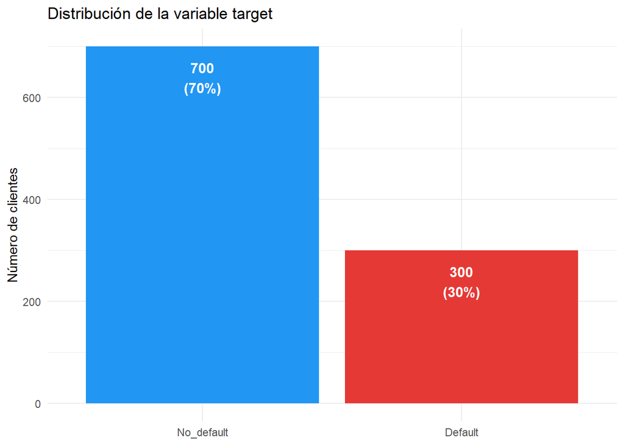

```r
# Graficamos
ggplot(credit, aes(x = default, fill = default)) +
  geom_bar() +
  geom_text(stat = "count",
            aes(label = paste0(after_stat(count), "\n(",
                               round(after_stat(count) / 1000 * 100, 1), "%)")),
            vjust = 1.5, color = "white", fontface = "bold", size = 4) +
  scale_fill_manual(values = c("No_default" = "#2196F3", "Default" = "#E53935")) +
  labs(title = "Distribución de la variable target",
       x = NULL, y = "Número de clientes") +
  theme_minimal() +
  theme(legend.position = "none")
```

Esto nos demuestra que el dataset está desbalanceado, el 70% de los casos corresponden a clientes “No default”, frente al 30% de “default”. Un modelo de clasificación sencillo que siempre predijera “No default” alcanzaría ya un 70% de accuracy sin aprender nada. Como se comenta al incio del documento, esta métrica por sí sola no será suficiente para evaluar el modelo.

**Distribución variables numéricas**

```r
# Estadísticos
summary(credit[, c("months_loan_duration", "amount", "age")])
```

```
##  months_loan_duration     amount           age
##  Min.   : 4.0         Min.   :  250   Min.   :19.00
##  1st Qu.:12.0         1st Qu.: 1366   1st Qu.:27.00
##  Median :18.0         Median : 2320   Median :33.00
##  Mean   :20.9         Mean   : 3271   Mean   :35.55
##  3rd Qu.:24.0         3rd Qu.: 3972   3rd Qu.:42.00
##  Max.   :72.0         Max.   :18424   Max.   :75.00
```

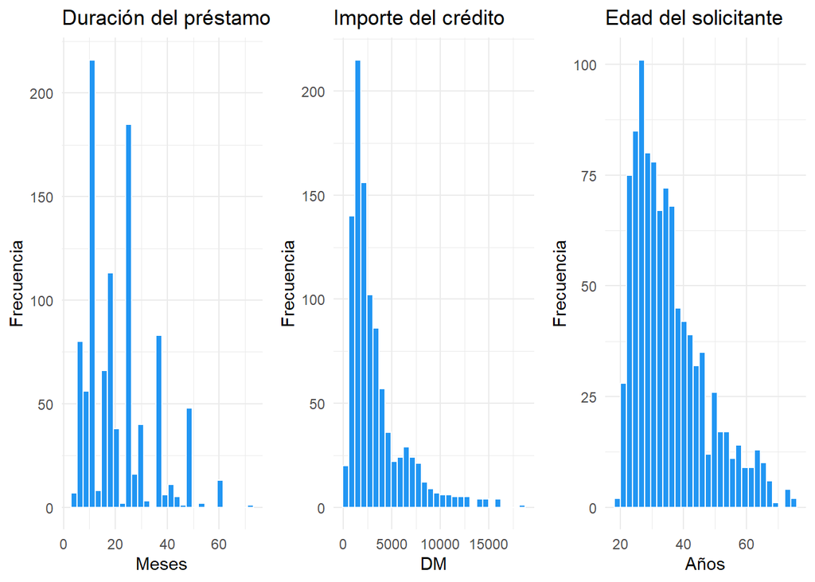

```r
# Graficamos
p_duration <- ggplot(credit, aes(x = months_loan_duration)) +
  geom_histogram(bins = 30, fill = "#2196F3", color = "white") +
  labs(title = "Duración del préstamo",
       x = "Meses", y = "Frecuencia") +
  theme_minimal()

p_amount <- ggplot(credit, aes(x = amount)) +
  geom_histogram(bins = 30, fill = "#2196F3", color = "white") +
  labs(title = "Importe del crédito",
       x = "DM", y = "Frecuencia") +
  theme_minimal()

p_age <- ggplot(credit, aes(x = age)) +
  geom_histogram(bins = 30, fill = "#2196F3", color = "white") +
  labs(title = "Edad del solicitante",
       x = "Años", y = "Frecuencia") +
  theme_minimal()

grid.arrange(p_duration, p_amount, p_age, ncol = 3)
```

Las tres variables numéricas continuas nos muestran patrones de distribución con asimetría positiva, es decir, con cola hacia la derecha, indicando que la mayoría de los clientes se concentran en valores bajos.

- **`months_loan_duration`:** La mayoría de préstamos tienen una duración de entre 12 y 24 meses, con picos claros en estos valores. Los préstamos con más de 48 meses de duración son minoritarios. Por lo que la distribución nos sugiere que los préstamos se conceden principalmente a corto-medio plazo.
- **`amount`:** Existe una fuerte concentración por debajo de los 5.000 DM, con una cola larga hacia importes más elevados. El importe mediano es de 2.320 DM frente a una media de 3.271, diferencia que ya refleja la asimetría de la distribución. Se ve una presencia de outliers, ya que se ven casos aislados por encima de 15.000 DM.
- **`age`:** Hay un pico alrededor de los 25-30 años, decayendo progresivamente hacia edades mayores. La mayoría de los solicitantes son adultos jóvenes, con muy pocos casos por encima de los 60 años. La mediana es de 33 años y la media de 35,5 años.

**Distribución univariante - variables categóricas**

Primero veremos un conteo de los distintos niveles de cada variable. Después graficaremos las distribuciones. Para ello, dado que son 13 variables, haremos 4 grids. Primero uno con las variables que tienen menos niveles, a continuación el resto, luego las dos variables con más niveles por separado para visualizarlas mejor y finalmente las 4 variables numéricas convertidas a factor:

```r
# Conteos por nivel
summary(credit[, sapply(credit, is.factor)])
```

```
##    checking_balance                credit_history       purpose
##  < 0 DM    :274     critical              :293    radio/tv  :280
##  > 200 DM  : 63     delayed               : 88    car (new) :234
##  1 - 200 DM:269     fully repaid          : 40    furniture :181
##  unknown   :394     fully repaid this bank: 49    car (used):103
##                     repaid                :530    business  : 97
##                                                   education : 50
##                                                   (Other)   : 55
##       savings_balance  employment_length installment_rate      personal_status
##  < 100 DM     :603    > 7 yrs   :253     1:136            divorced male: 50
##  > 1000 DM    : 48    0 - 1 yrs :172     2:231            female       :310
##  101 - 500 DM :103    1 - 4 yrs :339     3:157            married male : 92
##  501 - 1000 DM: 63    4 - 7 yrs :174     4:476            single male  :548
##  unknown      :183    unemployed: 62
##
##
##       other_debtors residence_history                     property
##  co-applicant: 41   1:130             building society savings:232
##  guarantor   : 52   2:308             other                   :332
##  none        :907   3:149             real estate             :282
##                     4:413             unknown/none            :154
##
##
##
##  installment_plan     housing    existing_credits       default    dependents
##  bank  :139       for free:108   1:633            No_default:700   1:845
##  none  :814       own     :713   2:333            Default   :300   2:155
##  stores: 47       rent    :179   3: 28
##                                  4:  6
##
##
##
##  telephone  foreign_worker                      job
##  none:596   no : 37        mangement self-employed:148
##  yes :404   yes:963        skilled employee       :630
##                            unemployed non-resident: 22
##                            unskilled resident     :200
##
##
##
```

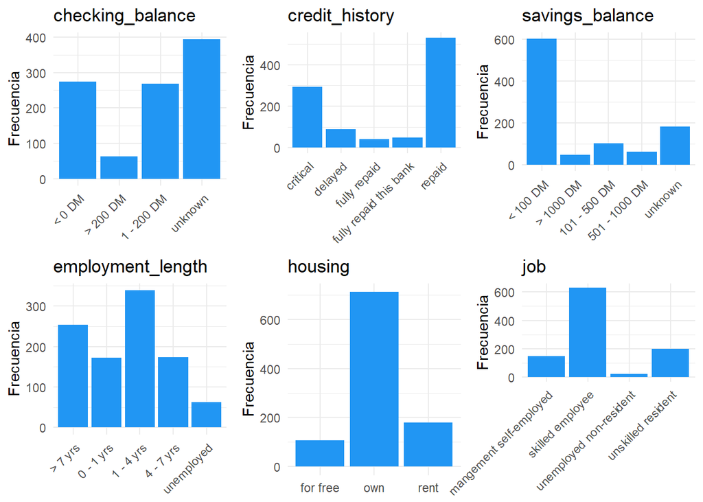

```r
# Grid 1: variables con pocos niveles
p_checking <- ggplot(credit, aes(x = checking_balance)) +
  geom_bar(fill = "#2196F3") +
  labs(title = "checking_balance", x = NULL, y = "Frecuencia") +
  theme_minimal() +
  theme(axis.text.x = element_text(angle = 45, hjust = 1))

p_history <- ggplot(credit, aes(x = credit_history)) +
  geom_bar(fill = "#2196F3") +
  labs(title = "credit_history", x = NULL, y = "Frecuencia") +
  theme_minimal() +
  theme(axis.text.x = element_text(angle = 45, hjust = 1))

p_savings <- ggplot(credit, aes(x = savings_balance)) +
  geom_bar(fill = "#2196F3") +
  labs(title = "savings_balance", x = NULL, y = "Frecuencia") +
  theme_minimal() +
  theme(axis.text.x = element_text(angle = 45, hjust = 1))

p_employment <- ggplot(credit, aes(x = employment_length)) +
  geom_bar(fill = "#2196F3") +
  labs(title = "employment_length", x = NULL, y = "Frecuencia") +
  theme_minimal() +
  theme(axis.text.x = element_text(angle = 45, hjust = 1))

p_housing <- ggplot(credit, aes(x = housing)) +
  geom_bar(fill = "#2196F3") +
  labs(title = "housing", x = NULL, y = "Frecuencia") +
  theme_minimal()

p_job <- ggplot(credit, aes(x = job)) +
  geom_bar(fill = "#2196F3") +
  labs(title = "job", x = NULL, y = "Frecuencia") +
  theme_minimal() +
  theme(axis.text.x = element_text(angle = 45, hjust = 1))

grid.arrange(p_checking, p_history, p_savings,
             p_employment, p_housing, p_job,
             ncol = 3)
```

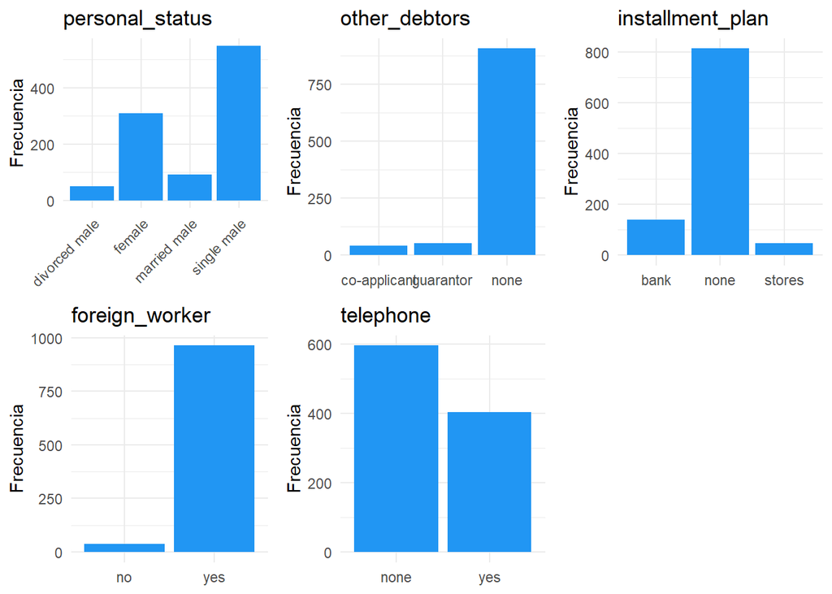

```r
# Grid 2: resto de variables
p_status <- ggplot(credit, aes(x = personal_status)) +
  geom_bar(fill = "#2196F3") +
  labs(title = "personal_status", x = NULL, y = "Frecuencia") +
  theme_minimal() +
  theme(axis.text.x = element_text(angle = 45, hjust = 1))

p_debtors <- ggplot(credit, aes(x = other_debtors)) +
  geom_bar(fill = "#2196F3") +
  labs(title = "other_debtors", x = NULL, y = "Frecuencia") +
  theme_minimal()

p_plan <- ggplot(credit, aes(x = installment_plan)) +
  geom_bar(fill = "#2196F3") +
  labs(title = "installment_plan", x = NULL, y = "Frecuencia") +
  theme_minimal()

p_foreign <- ggplot(credit, aes(x = foreign_worker)) +
  geom_bar(fill = "#2196F3") +
  labs(title = "foreign_worker", x = NULL, y = "Frecuencia") +
  theme_minimal()

p_telephone <- ggplot(credit, aes(x = telephone)) +
  geom_bar(fill = "#2196F3") +
  labs(title = "telephone", x = NULL, y = "Frecuencia") +
  theme_minimal()

grid.arrange(p_status, p_debtors, p_plan, p_foreign, p_telephone, ncol = 3)
```

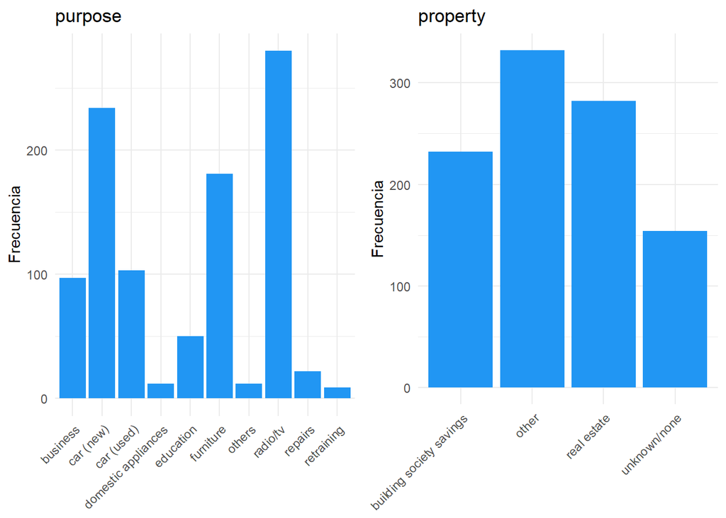

```r
# Grid 3: purpose y property:
p_property <- ggplot(credit, aes(x = property)) +
  geom_bar(fill = "#2196F3") +
  labs(title = "property", x = NULL, y = "Frecuencia") +
  theme_minimal() +
  theme(axis.text.x = element_text(angle = 45, hjust = 1))


p_purpose <- ggplot(credit, aes(x = purpose)) +
  geom_bar(fill = "#2196F3") +
  labs(title = "purpose", x = NULL, y = "Frecuencia") +
  theme_minimal() +
  theme(axis.text.x = element_text(angle = 45, hjust = 1))

grid.arrange(p_purpose, p_property, ncol=2)
```

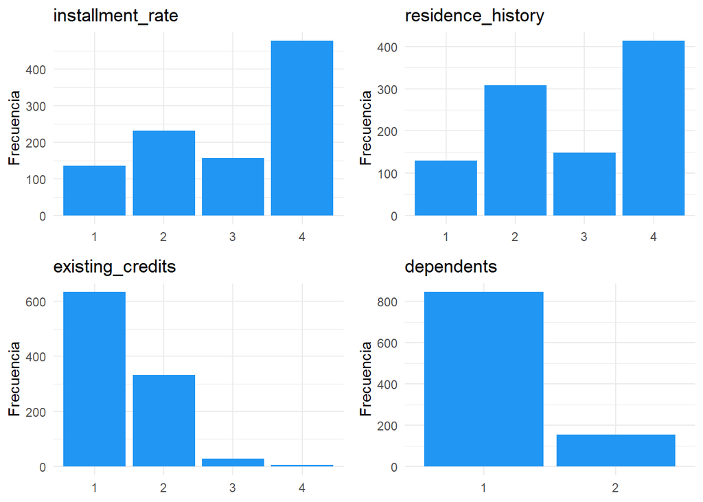

```r
# Grid 4: Variables numéricas convertidas a factor
p_inst_rate <- ggplot(credit, aes(x = installment_rate)) +
  geom_bar(fill = "#2196F3") +
  labs(title = "installment_rate", x = NULL, y = "Frecuencia") +
  theme_minimal()

p_residence <- ggplot(credit, aes(x = residence_history)) +
  geom_bar(fill = "#2196F3") +
  labs(title = "residence_history", x = NULL, y = "Frecuencia") +
  theme_minimal()

p_credits <- ggplot(credit, aes(x = existing_credits)) +
  geom_bar(fill = "#2196F3") +
  labs(title = "existing_credits", x = NULL, y = "Frecuencia") +
  theme_minimal()

p_dependents <- ggplot(credit, aes(x = dependents)) +
  geom_bar(fill = "#2196F3") +
  labs(title = "dependents", x = NULL, y = "Frecuencia") +
  theme_minimal()

grid.arrange(p_inst_rate, p_residence, p_credits, p_dependents, ncol = 2)
```

- **`checking_balance`:** La categoría más frecuente es `unknown` (394 clientes, 39.4%), que en el contexto del dataset indica ausencia de cuenta corriente. Le siguen 274 clientes con menos de 0 DM y 269 personas con un saldo de entre 1 y 200 DM. Solo 63 clientes poseen un saldo superior a 200 DM.
- **`credit_history`:** El 53% de los clientes tiene créditos previamente repaid. Destaca que 293 clientes tienen un historial clasificado como crítico, lo que sugiere que el banco concede créditos incluso a perfiles con historial problemático.
- **`savings_balance`:** 603 casos tienen menos de 100 DM, es decir, la mayoría de los solicitantes tienen escasos ahorros, lo que es relevante como predictor de riesgo.
- **`employment_length`:** predominan los empleados con antigüedad de entre 1 y 4 años (339) y con más de 7 años (253). Los desempleados son minoría (62 casos).
- **`housing`:** La mayoría de los clientes vive en una vivienda propia, el 71.3%.
- **`job`:** Dominan los ‘skilled employee’, siendo un 63%. Los `unemployed non-resident` son solo 22 casos, categoría muy minoritaria.
- **`personal_status`:** Predominan los hombres solteros con un 54.8%, seguidos de las mujeres con un 31%. La variable combina sexo y estado civil, lo que limita su interpretabilidad.
- **`other_debtors`:** El 90.7% de los clientes no tiene avalistas ni co-solicitantes. Nos encontramos ante una variable muy desbalanceadam con escasa variabilidad.
- **`installment_plan`:** El 81.4% de los clientes no tiene otros planes de pago activos (`none`).
- **`foreign_worker`:** Existe un aplastante 96.3% de clientes que son trabajadores extranjeros. Esta variable tiene muy poca variabilidad y probablemente no aporte mucho al modelo.
- **`telephone`:** El 59.6% no tiene teléfono registrado a nombre del cliente.
- **`property`:** Distribución bastante equilibrada entre `other` (332), `real state` (282) y `building society savings` (232). Solo 154 clientes no tienen ninguna propiedad registrada.
- **`purpose`:** El motivo más frecuente es `radio/tv` con 280 casos, seguido de coche nuevo con 234 y muebles con 181. Los préstamos para `retraining` y `domestic appliances` se pueden catalogar como “anecdóticos”.
- **`installment_rate`:** Casi la mitad de los clientes (47.6%) destina el mayor porcentaje de su renta disponible al pago de la cuota del préstamo. Los niveles 1 y 3 son los menos frecuentes.
- **`residence_history`:** Los niveles 2 y 4 (308 y 413 respectivamente), indican que los clientes tienden a llevar entre 1 y 4 años o más de 7 años en su residencia actual. El nivel 1 es el menos frecuente con 130 casos.
- **`existing_credits`:** La mayoría de los solicitantes tiene un único activo en el banco, el 63,3%. Tener 3 o más créditos es muy poco frecuente (34 casos en total), lo que convierte esta variable en poco discriminante para valores altos.
- **`dependents`:** El 84,5% de los clientes tiene solo 1 persona a cargo. Con apenas 155 casos en el nivel 2, esta variable presenta muy poca variabilidad y probablemente aportará escasa capacidad predictiva al modelo.

### 1.1.2 Análisis Bivariante

Una vez estudiada la distribución individual de cada variable, analizamos su relación con la variable target `default`. El objetivo es identificar qué variables pueden presentar diferencias claras entre clientes con y sin impago, para obtener una primera intuición sobre su capacidad predictiva antes de construir el modelo.

**Variables numéricas vs `default`**

Para las variables numéricas continuas utilizamos boxplots, que nos permitirán comparar la distribución de cada variable entre los dos grupos (Default vs No default) y detectar la presencia de valores atípicos. Ante la presencia de estos, habrá que tomar una decisión justificada sobre si imputarlos, eliminarlos o mantenerlos.

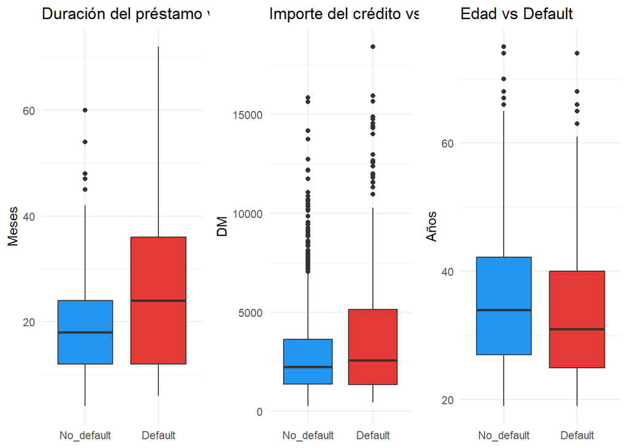

```r
# months_loan_duration
p_box_duration <- ggplot(credit, aes(x = default, y = months_loan_duration, fill = default)) +
  geom_boxplot() +
  scale_fill_manual(values = c("No_default" = "#2196F3", "Default" = "#E53935")) +
  labs(title = "Duración del préstamo vs Default",
       x = NULL, y = "Meses") +
  theme_minimal() +
  theme(legend.position = "none")

# amount
p_box_amount <- ggplot(credit, aes(x = default, y = amount, fill = default)) +
  geom_boxplot() +
  scale_fill_manual(values = c("No_default" = "#2196F3", "Default" = "#E53935")) +
  labs(title = "Importe del crédito vs Default",
       x = NULL, y = "DM") +
  theme_minimal() +
  theme(legend.position = "none")

# age
p_box_age <- ggplot(credit, aes(x = default, y = age, fill = default)) +
  geom_boxplot() +
  scale_fill_manual(values = c("No_default" = "#2196F3", "Default" = "#E53935")) +
  labs(title = "Edad vs Default",
       x = NULL, y = "Años") +
  theme_minimal() +
  theme(legend.position = "none")

grid.arrange(p_box_duration, p_box_amount, p_box_age, ncol = 3)
```

Visualizamos los valores concretos extremos:

```r
boxplot.stats(credit$months_loan_duration)$out
```

```
##  [1] 48 48 60 45 48 48 48 54 54 48 48 60 48 48 45 48 48 60 48 48 47 48 48 48 48
## [26] 48 48 60 48 60 60 48 48 48 48 48 48 48 48 48 48 60 48 60 48 48 48 60 72 60
## [51] 48 48 60 48 48 48 48 48 48 45 48 48 48 48 60 48 60 48 45 45
```

```r
boxplot.stats(credit$amount)$out
```

```
##  [1]  9055  8072 12579  9566 14421  8133  9436 12612 15945 11938  8487 10144
## [13]  8613  9572 10623 10961 14555  8978 12169 11998 10722  9398  9960 10127
## [25] 11590 13756 14782 14318 12976 11760  8648  8471 11328 11054  8318  9034
## [37]  8588  7966  8858 12389 12204  9157 15653  7980  8086 10222 10366  9857
## [49] 14027 11560 14179 12680  8065  9271  9283  9629 15857  8335 11816 10875
## [61]  9277 15672  8947 10477 18424 14896 12749 10297  8358 10974  8386  8229
```

```r
boxplot.stats(credit$age)$out
```

```
##  [1] 67 66 66 70 65 74 68 66 75 74 65 75 67 74 65 66 74 66 67 65 68 65 68
```

Los boxplots revelan la presencia de outliers en las tres variables numéricas. Teniendo en cuenta el contexto del dominio bancario, se trata de valores plausibles y reales: importes elevados, préstamos a largo plazo y clientes de edad avanzada son perfectamente posibles en este contexto. No se detectan errores evidentes de entrada de datos ni valores imposibles, por lo que se decide mantener todos los datos sin imputación alguna.  
Adicionalmente, los boxplots muestran diferencias relevantes entre grupos. Los clientes con Default tienden a solicitar préstamos de mayor importe y mayor duración que los clientes sin Default, sin embargo, la edad no muestra una separación tan clara entre los grupos.

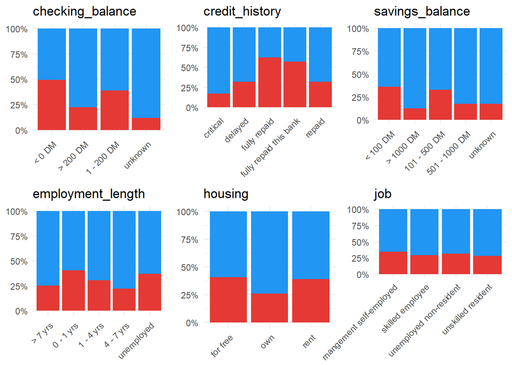

```r
# Función auxiliar para no repetir código
plot_biv <- function(var, titulo) {
  ggplot(credit, aes(x = .data[[var]], fill = default)) +
    geom_bar(position = "fill") +
    scale_fill_manual(values = c("No_default" = "#2196F3", "Default" = "#E53935")) +
    scale_y_continuous(labels = scales::percent) +
    labs(title = titulo, x = NULL, y = NULL, fill = NULL) +
    theme_minimal() +
    theme(axis.text.x = element_text(angle = 45, hjust = 1),
          legend.position = "none")
}

# Grid 1
grid.arrange(
  plot_biv("checking_balance", "checking_balance"),
  plot_biv("credit_history", "credit_history"),
  plot_biv("savings_balance", "savings_balance"),
  plot_biv("employment_length", "employment_length"),
  plot_biv("housing", "housing"),
  plot_biv("job", "job"),
  ncol = 3
)
```

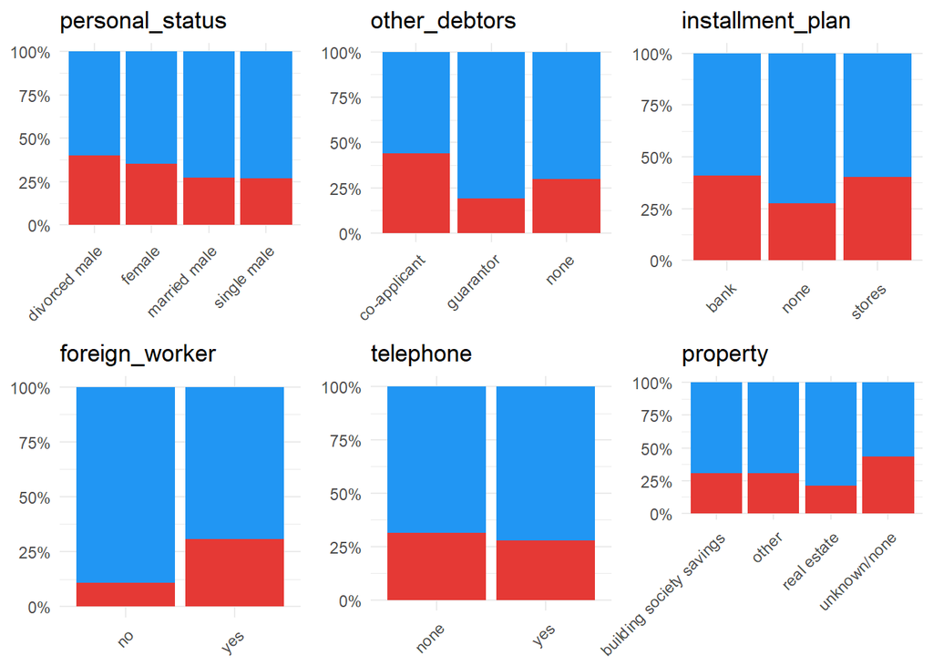

```r
# Grid 2
grid.arrange(
  plot_biv("personal_status", "personal_status"),
  plot_biv("other_debtors", "other_debtors"),
  plot_biv("installment_plan", "installment_plan"),
  plot_biv("foreign_worker",  "foreign_worker"),
  plot_biv("telephone", "telephone"),
  plot_biv("property", "property"),
  ncol = 3
)
```

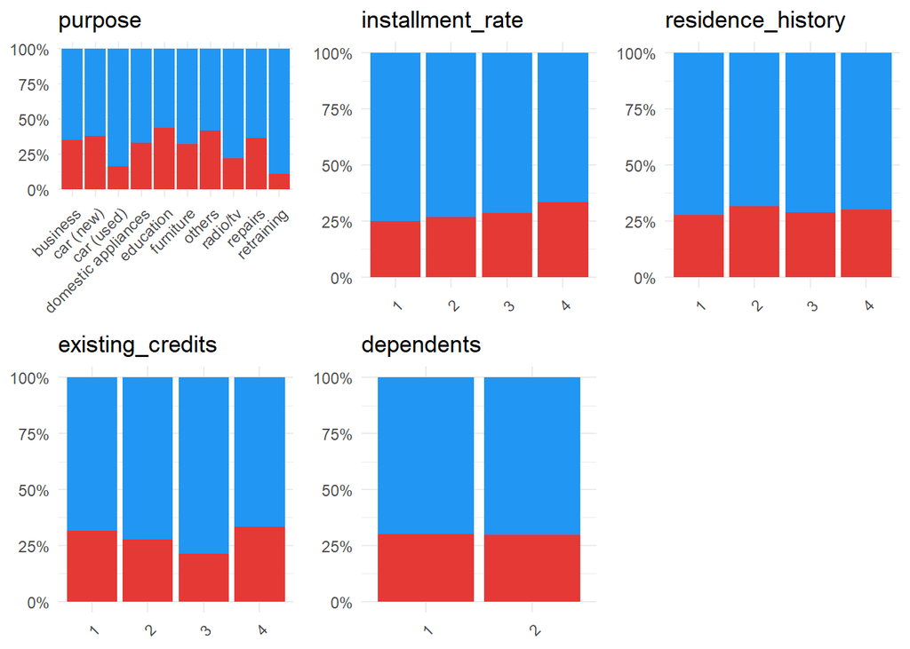

```r
# Grid 3
grid.arrange(
  plot_biv("purpose", "purpose"),
  plot_biv("installment_rate", "installment_rate"),
  plot_biv("residence_history", "residence_history"),
  plot_biv("existing_credits", "existing_credits"),
  plot_biv("dependents", "dependents"),
  ncol = 3
)
```

### 1.1.3 Tests estadísticos de asociación

Para poder cuantificar de una forma objetiva la relación entre cada variable predictora y el target, aplicamos tests estadísticos de asociación. Esto nos permite ir más allá de una simple inspección visual y así poder obtener un ranking comparable entre todas las variables.

Para las variables categóricas se utilizará la **V de Cramér**, una medida de asociación basada en el estadístico chi-cuadrado que toma valores entre 0 y 1, indicando “Sin asociación” y “Asociación perfecta” respectivamente. Como referencia orientativa: - $V < 0.1 \rightarrow$ Asociación débil - $0.1 \le V < 0.3 \rightarrow$ Asociación débil-moderada - $0.3 \le V < 0.5 \rightarrow$ Asociación moderada - $0.1 \ge 0.5 \rightarrow$ Asociación fuerte

Para las variables numéricas se utilizará el **Test de Wilcoxon** (Mann-Whitney), una alternativa no paramétrica al t-test más robusta ante distribuciones asimétricas como las que hemos podido observar. Un $p-valor < 0.05$ indica que las diferencias entre el grupo Default y No Default son estadísticamente significativas.

```r
library(DescTools)

# V de Cramér para todas las categóricas vs default
vars_cat <- c("checking_balance", "credit_history", "purpose",
              "savings_balance", "employment_length", "personal_status",
              "other_debtors", "property", "installment_plan", "housing",
              "telephone", "foreign_worker", "job", "installment_rate",
              "residence_history", "existing_credits", "dependents")

cramer_results <- data.frame(
  Variable   = vars_cat,
  CramerV    = sapply(vars_cat, function(v) {
    CramerV(table(credit[[v]], credit$default))
  })
) %>%
  arrange(desc(CramerV))

print(cramer_results)
```

```
##                            Variable     CramerV
## checking_balance   checking_balance 0.351739880
## credit_history       credit_history 0.248377529
## savings_balance     savings_balance 0.189997179
## purpose                     purpose 0.182637474
## property                   property 0.154011530
## employment_length employment_length 0.135529605
## housing                     housing 0.134906788
## installment_plan   installment_plan 0.113310140
## personal_status     personal_status 0.098006193
## foreign_worker       foreign_worker 0.082079499
## other_debtors         other_debtors 0.081519118
## installment_rate   installment_rate 0.074005352
## existing_credits   existing_credits 0.051683635
## job                             job 0.043418384
## telephone                 telephone 0.036466190
## residence_history residence_history 0.027373280
## dependents               dependents 0.003014853
```

```r
# Wilcoxon para las numéricas vs default
wilcox_amount   <- wilcox.test(amount   ~ default, data = credit)
wilcox_duration <- wilcox.test(months_loan_duration ~ default, data = credit)
wilcox_age      <- wilcox.test(age ~ default, data = credit)

data.frame(
  Variable  = c("amount", "months_loan_duration", "age"),
  p_valor   = c(wilcox_amount$p.value,
                wilcox_duration$p.value,
                wilcox_age$p.value)
)
```

```
##               Variable      p_valor
## 1               amount 5.917609e-03
## 2 months_loan_duration 7.981666e-11
## 3                  age 3.912774e-04
```

Los resultados confirman y matizan lo observado visualmente:

- **`checking_balance`** es con diferencia la variable categórica más asociada al target, seguida de **`credit_history`** y **`saving_balance`** con asociaciones débil-moderadas. En el extremo opuesto, `dependents` presenta una asociación prácticamente nula, confirmando lo que ya se veía en los gráficos.
- En cuanto a las variables numéricas, las tres muestran diferencias estadísticamente significativas entre clientes con y sin default. La más relevante de las tres con un p-valor extremadamente pequeño es `months_loan_duration`. Los préstamos de mayor duración se asocian con mayor riesgo de default.

### 1.1.4 Correlación entre variables numéricas

Los tests de Wilcoxon anteriores analizaban la relación de cada variable numérica con el target de forma individual. Ahora estudiaremos si existe relación entre las propias variables predictoras numéricas, es decir, si existe multicolinealidad. Recordemos que dos variables muy correlacionadas entre sí al aportar información redundante, pueden distorsionar la interpretación del modelo.

Dada la distribución asimétrica de las variables, utilizamos la correlación Spearman en lugar de la de Pearson. Spearman mide la correlación entre los rangos de los valores, siendo más robusta ante la falta de normalidad y la presencia de outliers.

```r
# Matriz de correlación
cor_matrix <- cor(credit[, c("months_loan_duration", "amount", "age")],
                  method = "spearman")  # Spearman por las distribuciones asimétricas
print(round(cor_matrix, 3))
```

```
##                      months_loan_duration amount    age
## months_loan_duration                1.000  0.625 -0.036
## amount                              0.625  1.000  0.026
## age                                -0.036  0.026  1.000
```

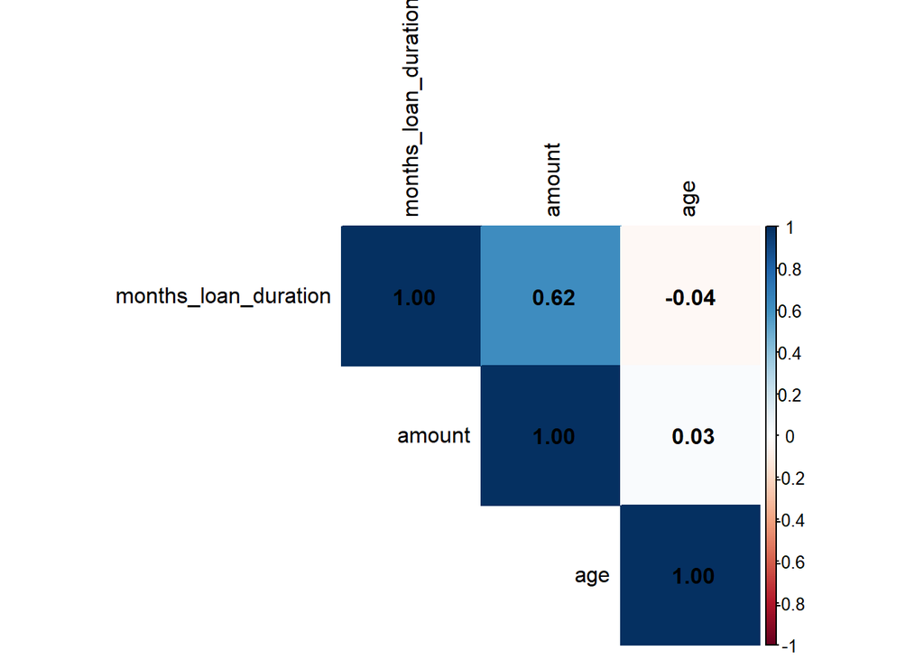

```r
# Visualización
library(corrplot)
corrplot(cor_matrix, method = "color", type = "upper",
         addCoef.col = "black", tl.col = "black")
```

Tras ver esta matriz de correlación de Spearman, se puede concluir que no existe una multicolinealidad problemática entre las variables numéricas. En todo caso, la única correlación destacable es entre `months_loan_duration` y `amount`, con una correlación positiva de 0.62, indicando que los préstamos de mayor importe tienden a concederse a plazos más largos. Esta correlación no es lo suficientemente alta como para considerar eliminar una de las dos variables, ya que ambas aportan información propia al modelo.

### 1.1.5 Tablas de contingencia

A partir del ranking obtenido en los tests estadísticos, profundizamos en las variables con mayor capacidad discriminante mediante tablas de contingencia. Estas tablas muestran la distribución conjunta de cada variable con `default`, permitiendo identificar qué categorías concretas concentra mayor riesgo de impago. Se analizan únicamente las variables con V de Cramér más elevada, ya que son las que aportarán mayor valor predictivo al modelo: `checking_balance`, `credit_history`, `savings_balance` y `purpose`.

```r
# Tablas de contingencia con proporciones por fila
vars_top4 <- c("checking_balance", "credit_history",
               "savings_balance", "purpose")

for (v in vars_top4) {
  cat("\n====", v, "====\n")
  t <- table(credit[[v]], credit$default)
  print(t)
  cat("\nProporciones por fila:\n")
  print(round(prop.table(t, margin = 1) * 100, 1))
}
```

```
##
## ==== checking_balance ====
##
##              No_default Default
##   < 0 DM            139     135
##   > 200 DM           49      14
##   1 - 200 DM        164     105
##   unknown           348      46
##
## Proporciones por fila:
##
##              No_default Default
##   < 0 DM           50.7    49.3
##   > 200 DM         77.8    22.2
##   1 - 200 DM       61.0    39.0
##   unknown          88.3    11.7
##
## ==== credit_history ====
##
##                          No_default Default
##   critical                      243      50
##   delayed                        60      28
##   fully repaid                   15      25
##   fully repaid this bank         21      28
##   repaid                        361     169
##
## Proporciones por fila:
##
##                          No_default Default
##   critical                     82.9    17.1
##   delayed                      68.2    31.8
##   fully repaid                 37.5    62.5
##   fully repaid this bank       42.9    57.1
##   repaid                       68.1    31.9
##
## ==== savings_balance ====
##
##                 No_default Default
##   < 100 DM             386     217
##   > 1000 DM             42       6
```

[output cut: 25 more lines]

```
##   retraining                   8       1
##
## Proporciones por fila:
##
##                       No_default Default
##   business                  64.9    35.1
##   car (new)                 62.0    38.0
##   car (used)                83.5    16.5
##   domestic appliances       66.7    33.3
##   education                 56.0    44.0
##   furniture                 68.0    32.0
##   others                    58.3    41.7
##   radio/tv                  77.9    22.1
##   repairs                   63.6    36.4
##   retraining                88.9    11.1
```

- **`checking_balance`:** A mayor saldo en la cuenta menor riesgo de impago. Los clientes con saldo negativo presentan la tasa de default más alta de todas las categorías de esa variable, un 49,3%, una proporción casi equiparable a la de no impago (50,7%). En el extremo opuesto, los clientes sin cuenta correinte tienen la tasa de impago más baja con solo un 11,7%. Los clientes con saldo entre 1 y 200 DM presentan un riesgo intermedio (39,0%), mientras que los que superan los 200DM se sitúan en el 22,2%.
- **`credit_history`:** Los clientes con un historial de `fully repaid`y `fully repaid this bank` presentan las tasas de impago más altas, superando incluso a los clientes con historial de `delayed` (31,8%). Estos datos son contraintuitivos, pero pueden significar que el banco relaje los requisitos para concederles créditos a estos perfiles y esto esté acabando en un escenario no deseado. Por otro lado, los clientes con historial “crítico” registran menos impagos (17.1%), esto puede ser debido a que el banco solo apruebe créditos a los mejores de ese grupo bajo filtros altamente estrictos.
- **`savings_balance`:** A mayor ahorro, menor tasa de impago. Los clientes con menos de 100 DM en ahorros presentan la tasa más alta (36%), mientras que los que tienen más de 1.000 DM presentan la más baja (12,5%). Destaca que los clientes sin cuenta de ahorros tienen una tasa de solo el 17,5% similar a los ahorradores de nivel medio-alto, lo que está sugiriendo una ausencia de necesidad de cuenta de ahorros más que ausencia de capacidad de ahorro.
- **`purpose`:** La finalidad del préstamo muestra diferencias relevantes entre categorías. Los préstamos para `education` presentan la tasa de default más alta entre los propósitos frecuentes (44.0%), seguidos de `car (new)` (38.0%) y `business` (35.1%). En el extremo opuesto, `car (used)` (16.5%) y `radio/tv` (22.1%) presentan las tasas más bajas. Una interpretación posible es que los coches usados implican importes menores y plazos más cortos, mientras que la educación supone una inversión a largo plazo con retorno incierto. Los propósitos con muy pocos casos (`retraining`, `domestic appliances`, `others`) deben interpretarse con cautela por su escasa representatividad estadística.

### 1.1.6 Conclusiones - Ranking de relevancia

Tras el análisis descriptivo, bivariante y los tests estadísticos, podemos establecer las siguientes conclusiones antes de abordar el modelado:

**Variables más relevantes** (V de Cramér > 0.15 o Wilcoxon significativo):

- `checking_balance` es la variable más discriminante del dataset (V=0.352). El saldo negativo en cuenta corriente es el indicador más claro de riesgo de impago.
- `credit_history` (V=0.248) y `savings_balance` (V=0.190) completan el top 3 de variables categóricas, confirmando que la situación financiera actual del cliente es más predictiva que su perfil sociodemográfico.
- `months_loan_duration` es la variable numérica más relevante (p=7.98e-11), seguida de `age` y `amount`.

**Variables de escasa utilidad predictiva:**

- `dependents` (V=0.003), `residence_history` (V=0.027) y `telephone` (V=0.036) presentan asociaciones prácticamente nulas con el target.
- `foreign_worker` y `other_debtors`, pese a mostrar diferencias visuales, tienen asociaciones débiles distorsionadas por el fuerte desbalance de sus categorías.

**Consideraciones para el modelado:**

- El dataset está **desbalanceado** (70/30), por lo que el accuracy no será la métrica principal de evaluación.
- No existe multicolinealidad problemática entre las variables numéricas.
- Se incluirán **todas las variables** en el modelo inicial, dejando que el propio algoritmo C5.0 seleccione las más relevantes mediante su mecanismo interno de poda.

**Matriz de costes asimétrica:**

Según la documentación original del dataset en el repositorio UCI Machine Learning Repository, el problema requiere el uso de una matriz de costes asimétrica:

|  | Predicho: Good (1) | Predicho: Bad (2) |
| --- | --- | --- |
| **Real: Good (1)** | 0 | 1 |
| **Real: Bad (2)** | 5 | 0 |

Clasificar un cliente malo como bueno (falso negativo) tiene un coste de **5**, cinco veces superior al coste de clasificar un cliente bueno como malo (falso positivo, coste **1**). Esto refuerza la necesidad de priorizar el **Recall sobre la clase Default** frente al accuracy global en todos los modelos que construiremos a continuación.

## 1.2 Árbol de decisión

Antes de construir el modelo, es necesario dividir el dataset en dos subconjuntos: uno de entrenamiento, con el que el algoritmo aprenderá los patrones, y uno de pruebas, que reservamos para evaluar la capacidad predictiva del modelo sobre datos no vistos.

Siguiendo el enfoque del ejemplo, se utilizará una proporción 2/3 - 1/3. Además, se fija una semilla para garantizar la reproducibilidad del análisis (`set.seed(20252`)).

Se elige el algoritmo **C5.0** frente a otras implementaciones de árboles como CART o rpart por su manejo nativo de variables categóricas sin necesidad de codifiación previa, su mecanismo de poda automática basado en el criterio de confianza de Quinlan, y por su capacidad para generar tanto árboles como reglas interpretables directamente.

```r
# Fijamos semilla
set.seed(20252)

# Separamos target y variables predictoras
y <- credit$default
x <- credit[, names(credit) != "default"]

# Split 2/3
split_prop <- 3
indexes <- sample(1:nrow(credit), size = floor(((split_prop - 1) / split_prop) * nrow(credit)))

trainX<-x[indexes,]
trainy<-y[indexes]
testX<-x[-indexes,]
testy<-y[-indexes]

# Verificamos dimensiones
dim(trainX)
```

```
## [1] 666  20
```

```r
dim(testX)
```

```
## [1] 334  20
```

```r
# Verificamos proporciones
prop.table(table(trainy))
```

```
## trainy
## No_default    Default
##  0.7027027  0.2972973
```

```r
prop.table(table(testy))
```

```
## testy
## No_default    Default
##  0.6946108  0.3053892
```

El dataset se divide en 666 casos para entrenamiento (2/3) y 334 para test (1/3). Además, después de ejecutar la extracción aleatoria, hemos verificado que la distribución de la variable objetivo se mantiene estable en ambos subconjuntos:

- **Train**: 70.3% No_default / 29.7% Default (468 / 198 casos)
- **Test**: 69.5% No_default / 30.5% Default (232 / 102 casos)

```r
# Verificamos que trainy es factor ya que C5.0 requiere que la variable target sea factor
class (trainy)
```

```
## [1] "factor"
```

```r
levels(trainy)
```

```
## [1] "No_default" "Default"
```

Con los datos de entrenamiento preparados, construimos el primer árbol de decisión utilizando el algoritmo **C5.0**, una implementación moderna del algoritmo ID3 de Quinlan que incorpora poda automática (con un criterio de confianza, CF, por defecto de 0.25) y manejo nativo de variables categóricas.

Se incluyen todas las variables predictoras en este primer modelo, dejando que el propio algoritmo seleccione las más informativas mediante su mecanismo interno de ganancia de información.

```r
# Creamos el árbol sin reglas
model_tree <- C5.0(trainX, trainy)
summary(model_tree)
```

```
##
## Call:
## C5.0.default(x = trainX, y = trainy)
##
##
## C5.0 [Release 2.07 GPL Edition]      Thu May 28 09:18:38 2026
## -------------------------------
##
## Class specified by attribute `outcome'
##
## Read 666 cases (21 attributes) from undefined.data
##
## Decision tree:
##
## checking_balance in {> 200 DM,unknown}: No_default (313/40)
## checking_balance in {< 0 DM,1 - 200 DM}:
## :...foreign_worker = no: No_default (12/1)
##     foreign_worker = yes:
##     :...other_debtors = guarantor:
##         :...months_loan_duration <= 21: No_default (15)
##         :   months_loan_duration > 21:
##         :   :...checking_balance = < 0 DM: No_default (8/2)
##         :       checking_balance = 1 - 200 DM: Default (3)
##         other_debtors = co-applicant:
##         :...personal_status in {divorced male,female}: Default (4)
##         :   personal_status = married male: No_default (1)
##         :   personal_status = single male:
##         :   :...job = skilled employee: Default (4)
##         :       job in {unemployed non-resident,
##         :       :       unskilled resident}: No_default (2)
##         :       job = mangement self-employed:
##         :       :...existing_credits in {1,3,4}: No_default (2)
##         :           existing_credits = 2: Default (2)
##         other_debtors = none:
##         :...credit_history in {fully repaid,
##             :                  fully repaid this bank}: Default (37/9)
##             credit_history = critical:
##             :...months_loan_duration <= 28: No_default (54/10)
##             :   months_loan_duration > 28: Default (11/4)
##             credit_history in {delayed,repaid}:
```

[output cut: 45 more lines]

```
##  100.00% checking_balance
##   53.00% foreign_worker
##   51.20% other_debtors
##   45.05% credit_history
##   27.33% months_loan_duration
##   15.32% amount
##   15.32% job
##   14.41% savings_balance
##    4.05% property
##    2.25% personal_status
##    2.25% housing
##    0.60% existing_credits
##
##
## Time: 0.0 secs
```

El árbol C5.0 entrenado con los datos de entrenamiento (666 casos) ha generado un árbol de 24 nodos hoja con una tasa de error del 16,5%, lo que equivale a un accuracy en train del 83,5%.

**Estructura del árbol**

La variable raíz es `checking_balance`, que divide inmediatamente el árbol en dos grandes ramas:

- Clientes con saldo superior a 200 DM o `unknown` (313 casos): que se clasifican directamente como No_default con una tasa de error del 12,8% (40/313). Esta rama cubre el 47% del train con una única condición, lo que confirma que `checking_balance` es la variable más discriminante del dataset.
- Clientes con saldo inferior a 0 DM o entre 1 y 200 DM: El árbol profundiza usando las variables `foreign_worker`, `other_debtors`, `credit_history`, `months_loan_duration`, `amount`, `job`, `savings_balance` y `property` para refinar la clasificación.

**Matriz de confusión**

De los 110 errores cometidos en el entrenamiento, 41 son falsos positivos (clientes pagadores clasificados como Default) y **69 falsos negativos** (clientes que no pagan clasificados como pagadores). Aplicando la matriz de costes asimétrica (FN=5, FP=1), estos 69 casos representan el error más costoso para el negocio.

Procedemos a visualizar el árbol:

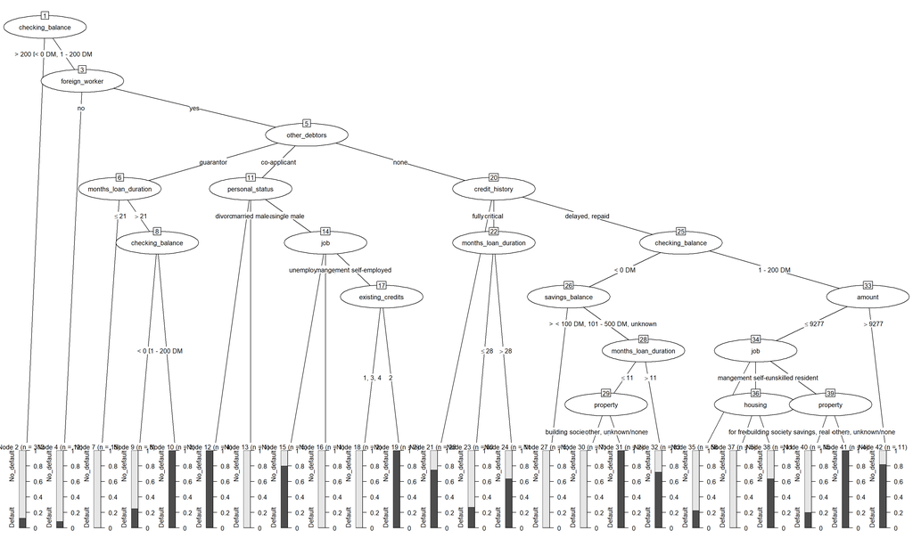

```r
library(partykit)
plot(as.party(model_tree), gp = gpar(fontsize = 10))
```

La visualización del árbol confirma la estructura descrita anteriormente. La variable raíz es `checking_balance`, que divide el árbol en dos ramas principales:

- **Rama izquierda** (saldo `> 200 DM` o `unknown`): clasificación directa como No_default sin necesidad de evaluar más variables.
- **Rama derecha** (saldo `< 0 DM` o `1 - 200 DM`): el árbol profundiza sucesivamente en `foreign_worker`, `other_debtors`, `credit_history`, `months_loan_duration`, `savings_balance`, `amount`, `job`, `property` y `housing`, refinando la clasificación según el perfil del cliente.

Cada nodo hoja muestra la distribución de probabilidad entre No_default y Default, permitiendo identificar visualmente los perfiles de mayor riesgo en las hojas con mayor proporción de Impago.

## 1.3 Reglas del árbol de decisión

El algoritmo C5.0 permite extraer el conocimiento aprendido en forma de **reglas de decisión** en lugar de una estructura de árbol. Cada regla es una condición independiente del tipo “Si… Entonces…” que asigna un caso a una clase con una confianza determinada.

Cada regla tiene 3 elementos:

- **Soporte:** nº de casos del train que cumplen las condiciones de la regla.
- **Confianza:** proporción de esos casos que pertenecen realmente a la clase predicha.
- **Lift:** La cantidad de veces que aumenta la probabilidad de acertar la clase predicha en comparación con el promedio general de los datos. Por ejemplo, un lift de 2.0 significa que la regla es el doble de precisa que predecir siempre la clase mayoritaria.

```r
# Modelo con extracción de reglas de decisión
model_rules<- C50::C5.0(trainX, trainy,rules=TRUE )
summary(model_rules)
```

```
##
## Call:
## C5.0.default(x = trainX, y = trainy, rules = TRUE)
##
##
## C5.0 [Release 2.07 GPL Edition]      Thu May 28 09:18:40 2026
## -------------------------------
##
## Class specified by attribute `outcome'
##
## Read 666 cases (21 attributes) from undefined.data
##
## Rules:
##
## Rule 1: (22/1, lift 1.3)
##  foreign_worker = no
##  ->  class No_default  [0.917]
##
## Rule 2: (644/197, lift 1.0)
##  foreign_worker = yes
##  ->  class No_default  [0.693]
##
## Rule 3: (6, lift 2.9)
##  checking_balance = 1 - 200 DM
##  property = other
##  job = unskilled resident
##  ->  class Default  [0.875]
##
## Rule 4: (12/1, lift 2.9)
##  checking_balance = 1 - 200 DM
##  credit_history in {delayed, repaid}
##  amount > 9277
##  ->  class Default  [0.857]
##
## Rule 5: (4, lift 2.8)
##  checking_balance in {< 0 DM, 1 - 200 DM}
##  personal_status = single male
##  other_debtors = co-applicant
##  job = skilled employee
##  ->  class Default  [0.833]
```

[output cut: 60 more lines]

```
##
##  100.00% foreign_worker
##   28.83% checking_balance
##   25.53% other_debtors
##   20.57% months_loan_duration
##   19.82% credit_history
##   12.31% savings_balance
##    4.65% job
##    3.15% housing
##    1.80% amount
##    1.20% personal_status
##    0.90% property
##
##
## Time: 0.0 secs
```

```r
# Importancia de variables según C5.0 (% de casos en que interviene cada variable)
C5imp(model_rules, metric = "usage")
```

```
##                      Overall
## foreign_worker        100.00
## checking_balance       28.83
## other_debtors          25.53
## months_loan_duration   20.57
## credit_history         19.82
## savings_balance        12.31
## job                     4.65
## housing                 3.15
## amount                  1.80
## personal_status         1.20
## property                0.90
## purpose                 0.00
## employment_length       0.00
## installment_rate        0.00
## residence_history       0.00
## age                     0.00
## installment_plan        0.00
## existing_credits        0.00
## dependents              0.00
## telephone               0.00
```

El modelo ha generado 11 reglas con una tasa de error de entrenamiento del 16,8% (112 casos mal clasificados de los 666).  
De las 11 reglas, las 2 primeras clasifican como No_default y las 9 restantes identifican perfiles de Default:

**Interpretación en lenguaje de negocio:**

- **Regla 1** (22 casos, confianza 91.7%): Los clientes no extranjeros son buenos pagadores con alta probabilidad.
- **Regla 2** (644 casos, confianza 69.3%): Los clientes extranjeros tienden a ser buenos pagadores, aunque con una confianza apenas superior a la proporción base del dataset. Regla por defecto del modelo.
- **Regla 3** (6 casos, confianza 87.5%): Un cliente con saldo bajo, sin activos relevantes y con empleo no cualificado tiene un 87.5% de probabilidad de impago.
- **Regla 4** (12 casos, confianza 85.7%): Un cliente con saldo bajo que solicita un importe elevado (>9.277 DM) con historial no excelente tiene un 85.7% de probabilidad de impago.
- **Regla 5** (4 casos, confianza 83.3%): Un hombre soltero con saldo bajo que solicita crédito con co-solicitante, aun teniendo empleo cualificado, tiene un 83.3% de probabilidad de impago.
- **Regla 6** (4 casos, confianza 83.3%): Una mujer trabajadora extranjera con saldo bajo que solicita crédito con co-solicitante tiene un 83.3% de probabilidad de impago.
- **Regla 7** (3 casos, confianza 80%): Un cliente con saldo bajo que necesita avalista para un préstamo de más de 21 meses tiene un 80% de probabilidad de impago.
- **Regla 8** (38 casos, confianza 75%): Un cliente con saldo bajo que ha saldado todos sus créditos anteriores y no tiene avalista tiene un 75% de probabilidad de impago.
- **Regla 9** (82 casos, confianza 71.4%): Un cliente extranjero con saldo negativo, pocos ahorros, sin avalista y con préstamo de más de 11 meses tiene un 71.4% de probabilidad de impago. **Perfil de riesgo más frecuente del dataset.**
- **Regla 10** (21 casos, confianza 60.9%): Un autónomo o directivo con vivienda propia pero saldo bajo tiene un 60.9% de probabilidad de impago.
- **Regla 11** (74 casos, confianza 59.2%): Un cliente con saldo bajo o negativo que solicita un préstamo de más de 28 meses sin avalista tiene un 59.2% de probabilidad de impago.

**Cobertura de las reglas** Las reglas 1 y 2 cubren conjuntamente el 100% de los casos usando `foreign_worker`. Esto explica por qué esta variable aparece son un uso del 100% en el Attribute usage, aunque como ya vimos en el análisis exploratorio su V de Cramér era baja (0.082). No es que sea muy discriminante, sino que actúa como regla por defecto del modelo.

Entre las reglas de Default, la regla 9 es la de mayor alcance con 82 casos y una confianza del 71,4%, seguida de la regla 11 con 74 casos y una confianza del 59,2%. En el extremo opuesto, las reglas 5, 6 y 7 cubren a penas 3-4 casos cada una, ya que son reglas muy precisas pero de escaso impacto práctico.

**Patrones más interesantes**

- `checking_balance` aparece en 9 de las 11 reglas, confirmando su papel central como predictor de riesgo, en línea con lo visto en el EDA.
- Las reglas 8 y 9 confirman el patrón contraintuitivo detectado anteriormente: cientes con historial `fully repaid` presentan alta tasa de impago (75% de confianza, 38 casos).
- Las reglas 9 y 11 apuntan al mismo patrón de fondo: el saldo bajo o negativo combinado con préstamos a medio-largo plazo es el principal indicador de riesgo, independientemente de otras características del cliente.
- Las reglas con mayor lift (2,9) son las reglas 3 y 4, es decir, predicen el impago casi 3 veces mejor que el azar, aunque con muy pocos casos (6 y 12 respectivamente).
- El modelo ha ignorado completamente variables como `age`, `purpose`, `installment_rate`, `residence_history` o `dependents`, también en línea con las bajas asociaciones detectadas en el EDA.

## 1.4 Bondad de ajuste

Una vez construido el modelo, es necesario evaluar su capacidad predictiva sobre datos que no han sido utilizados durante el entrenamiento, el conjunto de 334 casos. Esta evaluación nos dará una estimación realista del comportamiento del modelo realmente.

Se utilizará la matriz de confusión para analizar los tipos de error cometidos, y calcularemos métricas como Accuracy, Recall, Precisión y F1-Score.

```r
# Predicción sobre datos de test
pred <- predict(model_tree, testX)

# Matriz de confusión
CrossTable(testy, pred,
           prop.chisq = FALSE,
           prop.c = FALSE,
           prop.r = TRUE,
           dnn = c("Real", "Predicción"))
```

```
##
##
##    Cell Contents
## |-------------------------|
## |                       N |
## |           N / Row Total |
## |         N / Table Total |
## |-------------------------|
##
##
## Total Observations in Table:  334
##
##
##              | Predicción
##         Real | No_default |    Default |  Row Total |
## -------------|------------|------------|------------|
##   No_default |        185 |         47 |        232 |
##              |      0.797 |      0.203 |      0.695 |
##              |      0.554 |      0.141 |            |
## -------------|------------|------------|------------|
##      Default |         54 |         48 |        102 |
##              |      0.529 |      0.471 |      0.305 |
##              |      0.162 |      0.144 |            |
## -------------|------------|------------|------------|
## Column Total |        239 |         95 |        334 |
## -------------|------------|------------|------------|
##
##
```

Creamos una función para calcular las cuatro métricas para evaluar la bondad:

```r
# Función para calcular métricas
metricas <- function(real, predicho, clase_positiva = "Default") {

  tp <- sum(real == clase_positiva & predicho == clase_positiva)
  tn <- sum(real != clase_positiva & predicho != clase_positiva)
  fp <- sum(real != clase_positiva & predicho == clase_positiva)
  fn <- sum(real == clase_positiva & predicho != clase_positiva)

  accuracy  <- (tp + tn) / (tp + tn + fp + fn)
  precision <- tp / (tp + fp)
  recall    <- tp / (tp + fn)
  f1        <- 2 * (precision * recall) / (precision + recall)

  data.frame(
    Métrica = c("Accuracy", "Precision", "Recall", "F1"),
    Valor   = round(c(accuracy, precision, recall, f1), 3)
  )
}

# Aplicamos sobre las predicciones del modelo
metricas(testy, pred)
```

```
##     Métrica Valor
## 1  Accuracy 0.698
## 2 Precision 0.505
## 3    Recall 0.471
## 4        F1 0.487
```

Los resultados de la evaluación sobre el conjunto de test (334 casos) son los siguientes:

| Métrica | Valor |
| --- | --- |
| Accuracy | 69,8% |
| Precisión | 50,5% |
| Recall | 47,1% |
| F1-Score | 48,7% |

El modelo alcanza un **accuracy del 69.8%**, prácticamente idéntico a la proporción base del dataset (70% No_default). Esto significa que el modelo apenas mejora a un clasificador trivial que siempre predijera “No_default”, lo que es una señal de rendimiento limitado.

El dato más preocupante desde el punto de vista del negocio es el **Recall del 47.1%**: el modelo solo detecta correctamente 48 de los 102 clientes que realmente van a incumplir, clasificando los 54 restantes como buenos pagadores. El **F1-score de 48,7%** confirma el rendimiento mediocre para la clase Default, resultado del equilibrio entre una Precisión (50,5%) y un Recall (47,1%).

### 1.4.1 Conclusión

Podemos cuantificar el impacto económico real aplicando la matriz de costes asimétricas de la UCI:

|  | Casos | Coste unitario | Coste total |
| --- | --- | --- | --- |
| Falsos negativos (Default como No_default) | 54 | 5 | **270** |
| Falsos positivos (No_default como Default) | 47 | 1 | **47** |
| **Coste total del modelo** |  |  | **317** |

Como referencia, un clasificador trivial que siempre predijera No_default cometería 102 falsos negativos con un coste de **510 unidades**. El modelo reduce el coste en un **37,8%** respecto a no tener modelo alguno, lo que supone una mejora real. Sin embargo, este margen es claramente insuficiente para un entorno bancario real, ya que aprobar créditos a más de la mitad de los clientes que van a incumplir supondría pérdidas significativas.

Cabe destacar que todos los modelos de este análisis utilizan el **umbral de clasificación por defecto (0.5)**. Dado que la matriz de costes establece que un falso negativo es 5 veces más costoso que un falso positivo, en un entorno real sería reconmendable desplazar este umbral hacia valores menores, como 0.25. De esta manera se estaría forzando al modelo a ser más conservador al clasificar como No_default, incrementando así el Recall de la clase Default a costa de reducir la Precisión, sería como un *“trade-off”* justificado por la asimetría de costes del problema.

La curva ROC representa gráficamente la capacidad discriminante del modelo para distintos umbrales de clasificación, mostrando la tasa de verdaderos positivos (Recall) frente a la tasa de falsos positivos. El área bajo la curva (AUC) resume esta capacidad en un único valor entre 0 y 1, donde 0.5 equivale a clasificación aleatoria y 1.0 a clasificación perfecta:

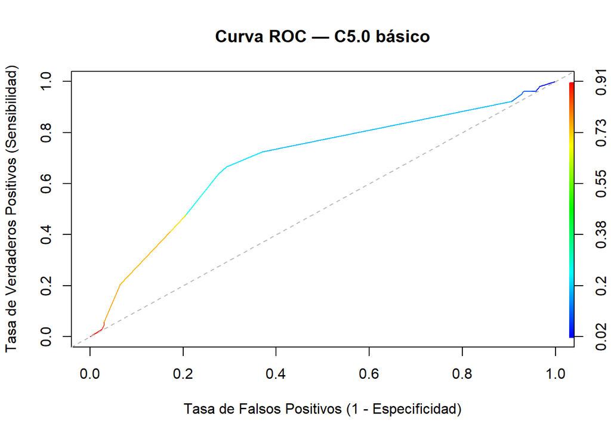

```r
# Curva ROC y AUC
pred_prob <- predict(model_tree, testX, type = "prob")[, "Default"]
pred_rocr <- prediction(pred_prob, testy,
                        label.ordering = c("No_default", "Default"))
perf <- performance(pred_rocr, "tpr", "fpr")

plot(perf, colorize = TRUE,
     main = "Curva ROC — C5.0 básico",
     xlab = "Tasa de Falsos Positivos (1 - Especificidad)",
     ylab = "Tasa de Verdaderos Positivos (Sensibilidad)")
abline(a = 0, b = 1, lty = 2, col = "gray")
```

```r
auc <- performance(pred_rocr, "auc")@y.values[[1]]
cat("AUC:", round(auc, 3))
```

```
## AUC: 0.689
```

El modelo obtiene un AUC de 0,689, lo que indica una capacidad discriminante moderada. El modelo es mejor que la clasificación aleatoria (AUC = 0.5) pero está lejos de un clasificador ideal (AUC =1.0). La curva ROC muestra que el modelo consigue una sensibilidad razonable para tasas de falsos positivos bajas (tramo inicial de la curva), pero se deteriora progresivamente a medida que se relaja el umbral de clasificación.

Este valor de AUC, combinado con el Recall de 47,1% y el coste económico de 317 unidadesm confirma que el modelo C5.0 básico tiene margen de mejora significativo. Lo usaremos como **línea base** para comprarar los modelos alternativos del apartado siguiente.

## 1.5 Árboles de decisión complementarios

El modelo C5.0 básico construido anteriormente ha mostrado un rendimiento limitado, con un Recall de 47,1% y un coste económico de 317 unidades. Con el objetivo de mejorar la capacidad predictiva, especialmente en la detección de clientes con riesgo de impago, exploraremos tres modelos alternativos utilizando las mismas variables predictoras:

- **C5.0 con pruning:** variante del modelo original con un umbral de confianza más restrictivo, que genera un árbol más simple y generalizable. Además de buscar una mejora de rendimiento, esta versión permitirá obtener una visualización más legible del árbol.
- **Random Forest:** modelo de ensamble basado en la combinación de múltiples árboles de decisión entrenados sobre muestras aleatorias del dataset. Su capacidad para reducir el sobreajuste y capturar relaciones complejas lo convierte en una referencia habitual en problemas de clasificación como este.
- **XGBoost:** algoritmo de gradient boosting que construye árboles de forma secuencial, donde cada árbol corrige los errores del anterior. Es uno de los algoritmos más potentes en competiciones y entornos profesionales de machine learning.

Al finalizar el apartado se presentará una **tabla comparativa** de los cuatro modelos (incluyendo el C5.0 básico) con las mismas métricas: Accuracy, Precisión, Recall, F1-Score, AUC y coste económico, para determinar qué enfoque es más adecuado para este problema.

### 1.5.1 C5.0 - Pruning

```r
# C5.0 con poda agresiva: CF=0.10 reduce la complejidad del árbol (default CF=0.25)
model_pruning <- C5.0(trainX, trainy, control = C5.0Control(CF=0.10))
summary(model_pruning)
```

```
##
## Call:
## C5.0.default(x = trainX, y = trainy, control = C5.0Control(CF = 0.1))
##
##
## C5.0 [Release 2.07 GPL Edition]      Thu May 28 09:18:40 2026
## -------------------------------
##
## Class specified by attribute `outcome'
##
## Read 666 cases (21 attributes) from undefined.data
##
## Decision tree:
##
## checking_balance in {> 200 DM,unknown}: No_default (313/40)
## checking_balance in {< 0 DM,1 - 200 DM}:
## :...other_debtors = co-applicant: Default (16/6)
##     other_debtors = guarantor: No_default (29/5)
##     other_debtors = none:
##     :...credit_history in {fully repaid,
##         :                  fully repaid this bank}: Default (38/9)
##         credit_history = critical:
##         :...months_loan_duration <= 28: No_default (58/10)
##         :   months_loan_duration > 28: Default (11/4)
##         credit_history in {delayed,repaid}:
##         :...checking_balance = 1 - 200 DM:
##             :...amount <= 9277: No_default (93/27)
##             :   amount > 9277: Default (10/1)
##             checking_balance = < 0 DM:
##             :...savings_balance in {> 1000 DM,
##                 :                   501 - 1000 DM}: No_default (5)
##                 savings_balance in {< 100 DM,101 - 500 DM,unknown}:
##                 :...months_loan_duration <= 11: No_default (9/2)
##                     months_loan_duration > 11: Default (84/25)
##
##
## Evaluation on training data (666 cases):
##
##      Decision Tree
##    ----------------
##    Size      Errors
##
##      11  129(19.4%)   <<
##
##
##     (a)   (b)    <-classified as
##    ----  ----
##     423    45    (a): class No_default
##      84   114    (b): class Default
##
##
##  Attribute usage:
##
##  100.00% checking_balance
##   53.00% other_debtors
##   46.25% credit_history
##   24.32% months_loan_duration
##   15.47% amount
##   14.71% savings_balance
##
##
## Time: 0.0 secs
```

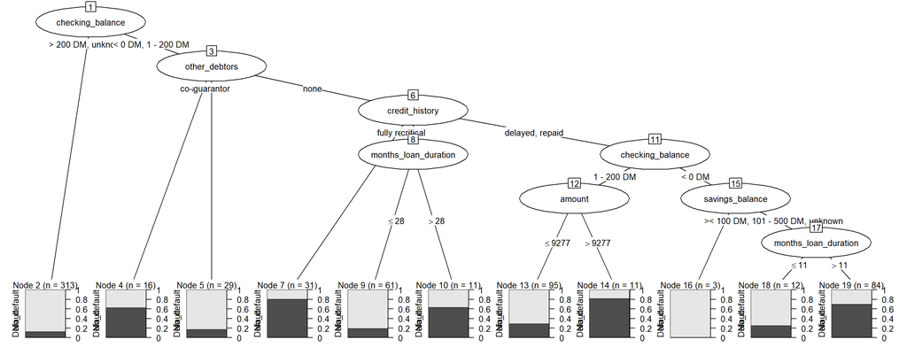

```r
# Graficamos
plot(as.party(model_pruning), gp=gpar(fontsize = 10))
```

Calculamos métricas de ajuste del modelo para comparar después:

```r
# Predicción en test
pred_pruning <- predict(model_pruning, testX)

# Matriz de confusión
CrossTable(testy, pred_pruning,
           prop.chisq = FALSE, prop.c = FALSE, prop.r = TRUE,
           dnn = c("Real", "Predicción"))
```

```
##
##
##    Cell Contents
## |-------------------------|
## |                       N |
## |           N / Row Total |
## |         N / Table Total |
## |-------------------------|
##
##
## Total Observations in Table:  334
##
##
##              | Predicción
##         Real | No_default |    Default |  Row Total |
## -------------|------------|------------|------------|
##   No_default |        187 |         45 |        232 |
##              |      0.806 |      0.194 |      0.695 |
##              |      0.560 |      0.135 |            |
## -------------|------------|------------|------------|
##      Default |         54 |         48 |        102 |
##              |      0.529 |      0.471 |      0.305 |
##              |      0.162 |      0.144 |            |
## -------------|------------|------------|------------|
## Column Total |        241 |         93 |        334 |
## -------------|------------|------------|------------|
##
##
```

```r
# Métricas
metricas(testy, pred_pruning)
```

```
##     Métrica Valor
## 1  Accuracy 0.704
## 2 Precision 0.516
## 3    Recall 0.471
## 4        F1 0.492
```

```r
# AUC
pred_prob_pruning <- predict(model_pruning, testX, type = "prob")[, "Default"]
pred_rocr_pruning <- prediction(pred_prob_pruning, testy,
                                label.ordering = c("No_default", "Default"))
auc_pruning <- performance(pred_rocr_pruning, "auc")@y.values[[1]]
cat("AUC:", round(auc_pruning, 3))
```

```
## AUC: 0.72
```

### 1.5.2 Random Forest

```r
library(randomForest)

set.seed(20252)
model_rf <- randomForest(x = trainX,
                         y = trainy,
                         ntree = 500,
                         importance = TRUE)
print(model_rf)
```

```
##
## Call:
##  randomForest(x = trainX, y = trainy, ntree = 500, importance = TRUE)
##                Type of random forest: classification
##                      Number of trees: 500
## No. of variables tried at each split: 4
##
##         OOB estimate of  error rate: 21.92%
## Confusion matrix:
##            No_default Default class.error
## No_default        440      28  0.05982906
## Default           118      80  0.59595960
```

En este caso tenemos 2 gráficos interesantes a visualizar:

- Un gráfico para ver a partir de cuantos árboles el error se estabiliza.
- Ver la relevancia de las variables según el RF, lo que podremos comparar con el ranking de V de Cramér del EDA y con el Attribute usage del C5.0:

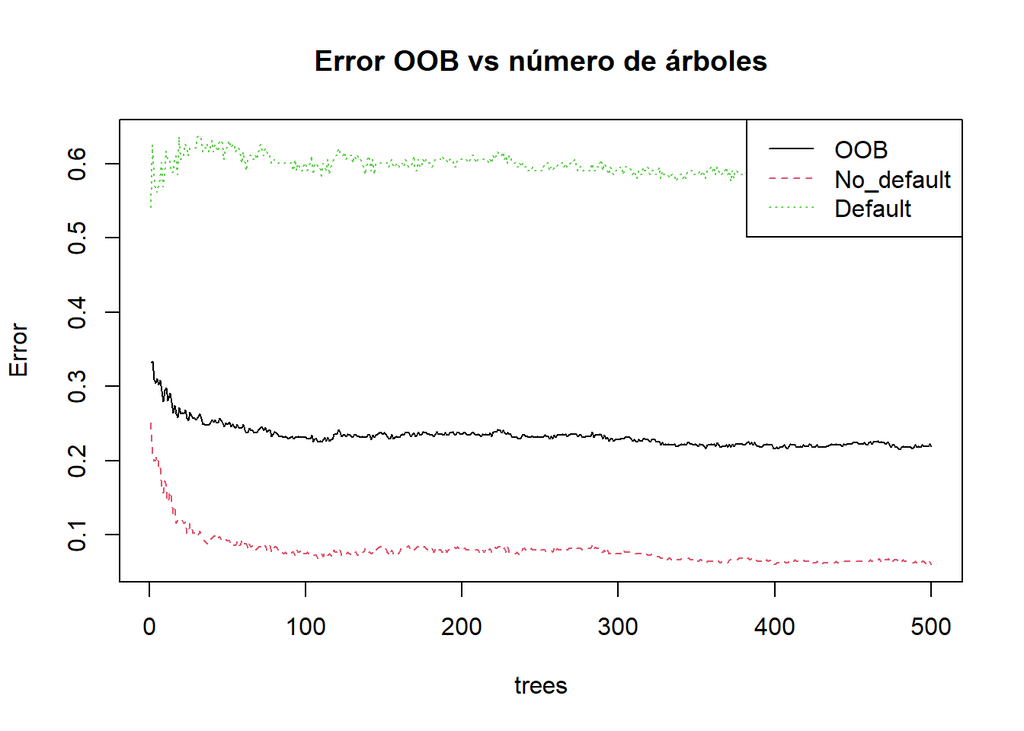

```r
# Gráfico 1: Error OOB vs número de árboles
plot(model_rf, main = "Error OOB vs número de árboles")
legend("topright", legend = colnames(model_rf$err.rate),
       col = 1:3, lty = 1:3)
```

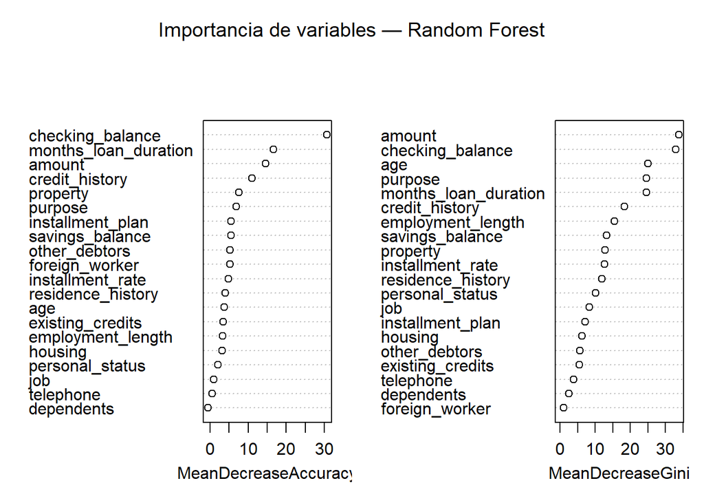

```r
# Gráfico 2: Importancia de variables
varImpPlot(model_rf, main = "Importancia de variables — Random Forest")
```

El error OOB global se estabiliza a partir de 100 árboles aproximadamente, lo que indica que 500 árboles es suficiente, de hecho, añadir más no mejoraría el modelo. Se aprecia claramente el problema de desbalance, el error para la clase No_default es muy bajo, mientras que el error para la clase Default se mantiene elevado durante todo el entrenamiento.

Calculamos las métricas para comparar después:

```r
# Predicción en test
pred_rf <- predict(model_rf, testX)

# Matriz de confusión
CrossTable(testy, pred_rf,
           prop.chisq = FALSE, prop.c = FALSE, prop.r = TRUE,
           dnn = c("Real", "Predicción"))
```

```
##
##
##    Cell Contents
## |-------------------------|
## |                       N |
## |           N / Row Total |
## |         N / Table Total |
## |-------------------------|
##
##
## Total Observations in Table:  334
##
##
##              | Predicción
##         Real | No_default |    Default |  Row Total |
## -------------|------------|------------|------------|
##   No_default |        207 |         25 |        232 |
##              |      0.892 |      0.108 |      0.695 |
##              |      0.620 |      0.075 |            |
## -------------|------------|------------|------------|
##      Default |         63 |         39 |        102 |
##              |      0.618 |      0.382 |      0.305 |
##              |      0.189 |      0.117 |            |
## -------------|------------|------------|------------|
## Column Total |        270 |         64 |        334 |
## -------------|------------|------------|------------|
##
##
```

```r
# Métricas
metricas(testy, pred_rf)
```

```
##     Métrica Valor
## 1  Accuracy 0.737
## 2 Precision 0.609
## 3    Recall 0.382
## 4        F1 0.470
```

```r
# AUC
pred_prob_rf <- predict(model_rf, testX, type = "prob")[, "Default"]
pred_rocr_rf <- prediction(pred_prob_rf, testy,
                           label.ordering = c("No_default", "Default"))
auc_rf <- performance(pred_rocr_rf, "auc")@y.values[[1]]
cat("AUC:", round(auc_rf, 3))
```

```
## AUC: 0.77
```

### 1.5.3 XGBoost

```r
library(xgboost)

# XGBoost requiere matrices numéricas
# Preparación de datos
X_all <- rbind(trainX, testX)
dummies <- dummyVars(~ ., data = X_all)
X_all_mat <- predict(dummies, X_all)
X_train <- X_all_mat[1:nrow(trainX), ]
X_test  <- X_all_mat[(nrow(trainX)+1):nrow(X_all_mat), ]

# Target como factor 0/1
trainy_xgb <- factor(as.numeric(trainy == "Default"), levels = c(0, 1))
testy_xgb  <- factor(as.numeric(testy  == "Default"), levels = c(0, 1))

# Entrenamos
set.seed(20252)
model_xgb <- xgboost(x         = X_train,
                     y         = trainy_xgb,
                     nrounds   = 100,
                     eval_metric = "logloss")

print(model_xgb)
```

```
## XGBoost model object
## Call:
##   xgboost(x = X_train, y = trainy_xgb, nrounds = 100, eval_metric = "logloss")
## Objective: binary:logistic
## Number of iterations: 100
## Number of features: 71
## Classes: 0, 1
```

[output not shown]

Graficamos:

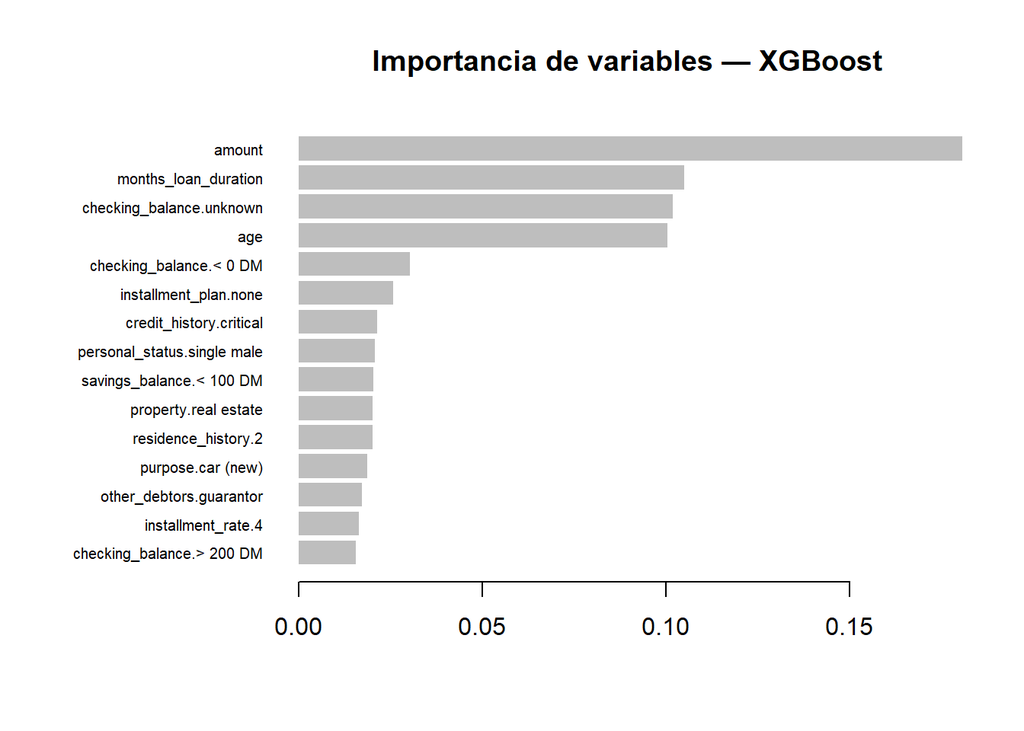

```r
# Importancia de variables
importance_xgb <- xgb.importance(model = model_xgb)
xgb.plot.importance(importance_xgb, top_n = 15,
                    main = "Importancia de variables — XGBoost")
```

Calculamos las métricas para comparar:

```r
# Predicción en test
prob_xgb  <- predict(model_xgb, X_test)
pred_xgb  <- factor(ifelse(prob_xgb > 0.5, 1, 0), levels = c(0, 1))
testy_01  <- factor(as.numeric(testy == "Default"), levels = c(0, 1))

# Matriz de confusión
CrossTable(testy_01, pred_xgb,
           prop.chisq = FALSE, prop.c = FALSE, prop.r = TRUE,
           dnn = c("Real", "Predicción"))
```

```
##
##
##    Cell Contents
## |-------------------------|
## |                       N |
## |           N / Row Total |
## |         N / Table Total |
## |-------------------------|
##
##
## Total Observations in Table:  334
##
##
##              | Predicción
##         Real |         0 |         1 | Row Total |
## -------------|-----------|-----------|-----------|
##            0 |       195 |        37 |       232 |
##              |     0.841 |     0.159 |     0.695 |
##              |     0.584 |     0.111 |           |
## -------------|-----------|-----------|-----------|
##            1 |        56 |        46 |       102 |
##              |     0.549 |     0.451 |     0.305 |
##              |     0.168 |     0.138 |           |
## -------------|-----------|-----------|-----------|
## Column Total |       251 |        83 |       334 |
## -------------|-----------|-----------|-----------|
##
##
```

```r
# Métricas
metricas(testy_01, pred_xgb, clase_positiva = "1")
```

```
##     Métrica Valor
## 1  Accuracy 0.722
## 2 Precision 0.554
## 3    Recall 0.451
## 4        F1 0.497
```

```r
# AUC
pred_rocr_xgb <- prediction(prob_xgb, testy_01,
                             label.ordering = c("0", "1"))
auc_xgb <- performance(pred_rocr_xgb, "auc")@y.values[[1]]
cat("AUC:", round(auc_xgb, 3))
```

```
## AUC: 0.759
```

### 1.5.4 Comparativa de modelos

| Modelo | Accuracy | Precision | Recall | F1-Score | AUC |
| --- | --- | --- | --- | --- | --- |
| C5.0 básico | 69.8% | 50.5% | 47.1% | 48.7% | 0.689 |
| C5.0 pruning (CF=0.10) | 70.4% | 51.6% | 47.1% | 49.2% | 0.720 |
| Random Forest | 73.7% | 60.9% | 38.2% | 47.0% | 0.770 |
| XGBoost | 72.2% | 55.4% | 45.1% | 49.7% | 0.759 |

Para poder determinar si hay un enfoque notablemente mejor que el de base, lo más útil es recurrir a la matriz de costes asimétrica.

Desde el punto de vista del **Recall**, la métrica más relevante dado que los falsos negativos cuestan 5 veces más que los falsos positivos, el C5.0 básico y el C5.0 pruning empatan en el mejor resultado (47,1%), seguidos del XGBoost (45,1%) y el Random Forest (38,2%). En este sentido, los modelos alternativos *“no mejoran”* al original en la métrica más importante para el negocio.

Sin embargo, si consideramos el **AUC** como métrica de capacidad discriminante global, el Random Forest (0.770) y el XGBoost (0.759) superan claramente al C5.0 básico (0.689). Esto indica que estos modelos tienen mejor capacidad para separar las dos clases en general, aunque con el umbral de clasificación por defecto (0.5) no se traduzca en mejor Recall.

Desde el punto de vista económico:

| Modelo | FN | FP | Coste (FN×5 + FP×1) |
| --- | --- | --- | --- |
| C5.0 básico | 54 | 47 | **317** |
| C5.0 pruning | 54 | 45 | **315** |
| Random Forest | 63 | 25 | **340** |
| XGBoost | 56 | 37 | **317** |

El modelo C5.0 pruning obtiene el menor Coste económico (315 unidades), aunque la diferencia con el básico es mínima. El Random Forest, pese a tener un mejor AUC, genera el mayor coste económico por sus numerosos falsos negativos.

**Conclusión**

Los resultados reflejan limitaciones inherentes del dataset: con solo 1.000 observaciones, 20 variables de poder predictivo moderado y un desbalance de clases del 70/30, ningún modelo consigue superar el 50% de Recall en la clase Default.

Por otro lado, destaca que el **XGBoost** identifica `amount` y `months_loan_duration` como las variables más importantes, mientras que el C5.0 sitúa a `checking_balance` en primer lugar. Esta discrepancia está reflejando las diferencias en cómo cada algoritmo captura las relaciones entre variables. *(El XGBoost al trabajar con variables dummy, puede capturar interacciones más granulares entre categorías específicas)*

Teniendo en cuenta el contexto bancario y la matriz de costes asimétrica, el modelo recomendado sería el **C5.0 con pruning**: genera el menor coste económico (315 unidades), es el más interpretable de los cuatro y mantiene el mismo Recall que el modelo básico con un árbol más simple y generalizable. El **Random Forest** es la alternativa si se prioriza la capacidad discriminante global (AUC 0.770), y el **XGBoost** si se busca el equilibrio entre métricas (mejor F1-Score).

En un banco real se complementarían con técnicas de balanceo de clases (SMOTE sobre el conjunto de entrenamiento), mayor volumen histórico de solicitudes, variables adicionales de comportamiento financiero (ratio deuda/ingresos verificado, historial de transacciones) y el ajuste del umbral de clasificación según la matriz de costes, aspectos que quedan fuera del alcance de esta práctica pero que serían el siguiente paso natural.

### 1.5.5 Métricas de explicabilidad

Más allá de las métricas de rendimiento global, es importante entender cómo y por qué los modelos toman sus decisiones. Las métricas de explicabilidad nos permiten interpretar el comportamiento del modelo tanto a nivel global (qué variables son más importantes en general) como a nivel local (por qué el modelo clasificó a un cliente concreto como Default o No_default).

Para ello utilizaremos el paquete `iml` sobre el Random Forest, por ser el modelo con mayor AUC (0.770), para poder calcular:

- **Importancia de variables del C5.0** (`attribute usage`): ya analizada en el apartado de reglas — mide el porcentaje de casos en los que cada variable interviene en las decisiones del árbol.
- **Feature Importance por permutación** (`iml`): mide cuánto empeora el modelo cuando se aleatoriza cada variable. Responde a la pregunta *“¿cuánto perdemos si eliminamos esta variable?”*
- **Efectos Locales Acumulados (ALE)**: visualizan cómo los distintos valores de una variable afectan a la probabilidad de Default, de forma más robusta que los gráficos de dependencia parcial ante variables correlacionadas.
- **SHAP** (SHapley Additive exPlanations): descompone la predicción de un caso concreto en la contribución individual de cada variable, permitiendo explicar **por qué** el modelo tomó una decisión específica para un cliente determinado. Es especialmente útil para auditar casos dudosos o explicar decisiones de crédito a nivel individual.

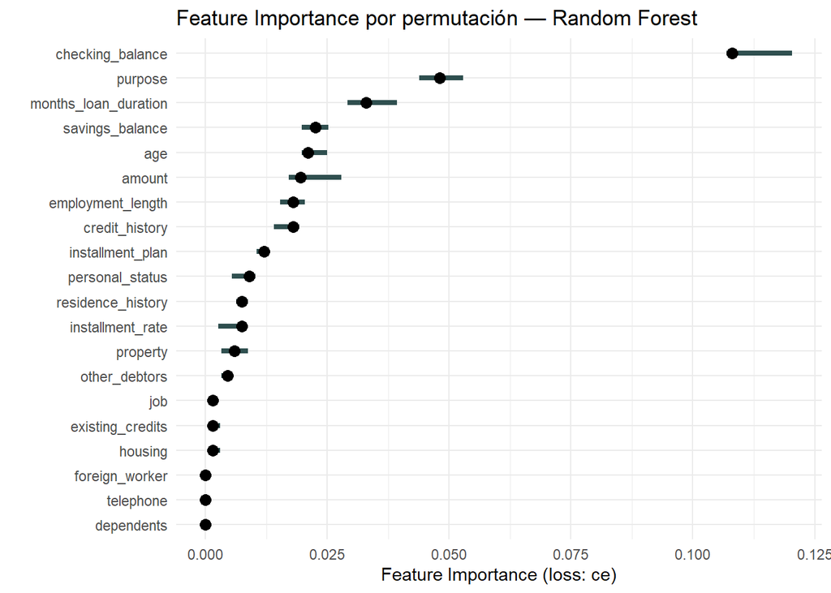

```r
library(iml)

# Creamos el predictor IML sobre el Random Forest
train_data <- cbind(trainX, default = trainy)

# Creamos el predictor IML sobre el Random Forest
predictor <- Predictor$new(
  model = model_rf,
  data  = trainX,
  y     = trainy,
  type  = "prob"
)

# Feature Importance por permutación

#Fijamos semilla:
set.seed(20252)
imp <- FeatureImp$new(predictor, loss = "ce")
plot(imp) +
  ggtitle("Feature Importance por permutación — Random Forest") +
  theme_minimal()
```

El gráfico confirma y enriquece los resultados. `checking_balance` es con diferencia la variable más importante (importancia alrededor de 0.10), seguida de `purpose`, `months_loan_duration` y `savings_balance`. Esto es coherente con la V de Cramér calculada en el EDA, donde `checking_balance` obtuvo el valor más alto (0.352).

En el extremo opuesto tenemos `dependents`, `telephone`, `foreign_worker`, `housing` y `existing_credits` presentan una importancia prácticamente nula, confirmando lo observado en el EDA.

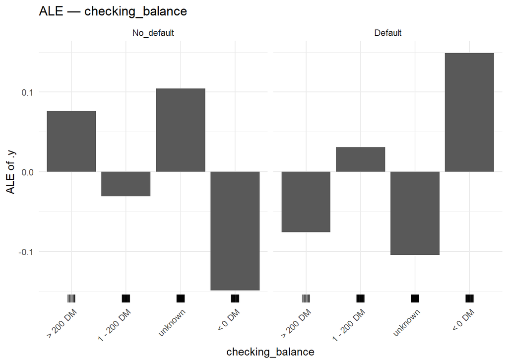

```r
# ALE plots para las 3 variables más importantes
ale_checking <- FeatureEffect$new(predictor,
                                   feature = "checking_balance",
                                   method = "ale")
plot(ale_checking) +
  ggtitle("ALE — checking_balance") +
  theme_minimal()+
  theme(axis.text.x = element_text(angle = 45, hjust = 1))
```

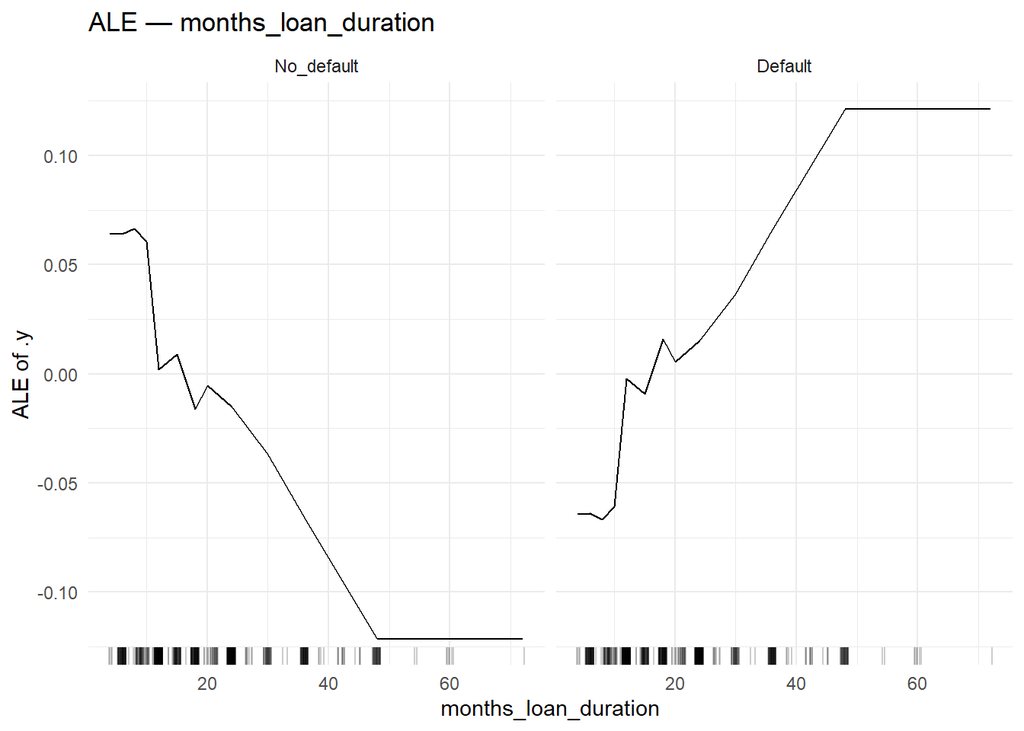

```r
ale_duration <- FeatureEffect$new(predictor,
                                   feature = "months_loan_duration",
                                   method = "ale")
plot(ale_duration) +
  ggtitle("ALE — months_loan_duration") +
  theme_minimal()
```

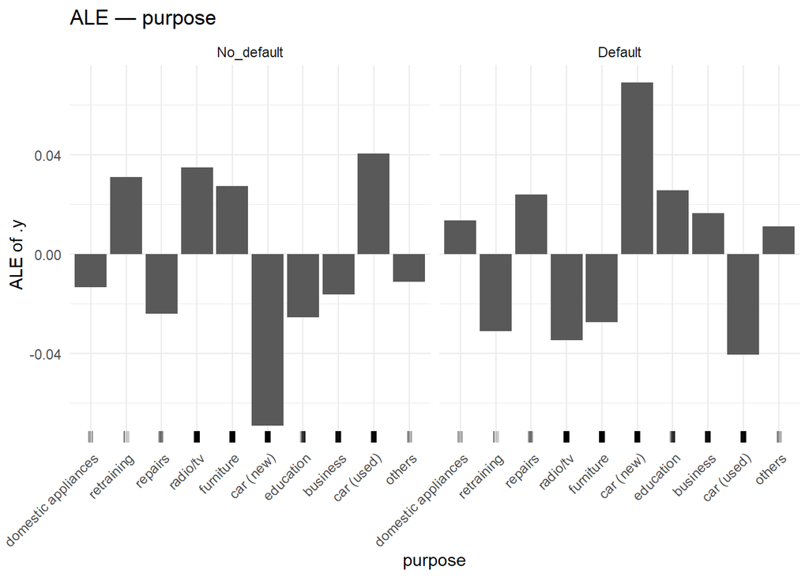

```r
ale_purpose <- FeatureEffect$new(predictor,
                                  feature = "purpose",
                                  method = "ale")
plot(ale_purpose) +
  ggtitle("ALE — purpose") +
  theme_minimal()+
  theme(axis.text.x = element_text(angle = 45, hjust = 1))
```

**ALE — `checking_balance`:** El gráfico confirma el patrón detectado en el análisis exploratorio. Tener saldo negativo aumenta considerablemente la probabilidad de Default, mientras que `unknown` y `> 200 DM` la reducen significativamente. El saldo en cuenta corriente tiene un efecto directo y claro sobre el riesgo de impago.

**ALE — `months_loan_duration`:** Se observa una relación clara: a mayor duración del préstamo, mayor probabilidad de Default. Los préstamos cortos favorecen el no impago, mientras que a partir de los 30 meses la probabilidad de Default aumenta progresivamente, estabilizándose en valores altos a partir de los 45 meses.

**ALE — `purpose`:** La finalidad del préstamo muestra efectos heterogéneos. `car (new)` y `education` son los propósitos que más aumentan la probabilidad de Default, mientras que `car (used)` y `radio/tv` la reducen. Esto coincide con lo observado en las tablas de contingencia: los coches usados implican importes menores y plazos más cortos, mientras que la educación supone una inversión a largo plazo con retorno incierto.

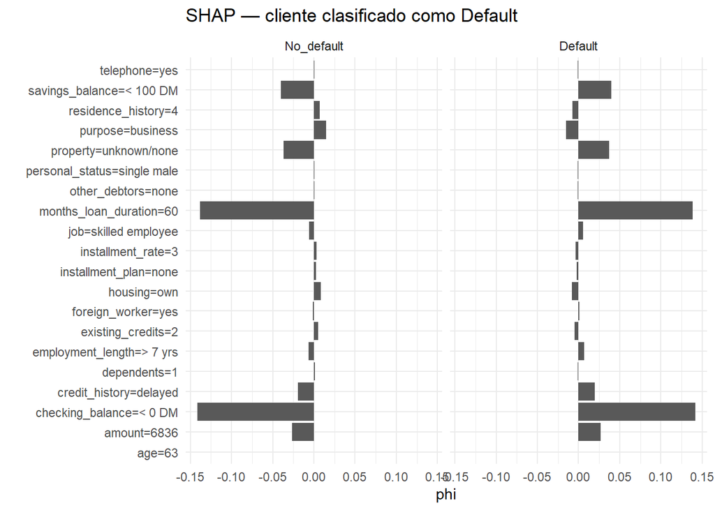

```r
# SHAP para un cliente con Default y uno sin Default
# Seleccionamos un caso de cada clase del test
caso_default    <- testX[which(testy == "Default")[1], ]
caso_nodefault  <- testX[which(testy == "No_default")[1], ]

# SHAP para el caso Default
shap_default <- Shapley$new(predictor, x.interest = caso_default)
plot(shap_default) +
  ggtitle("SHAP — cliente clasificado como Default") +
  theme_minimal()
```

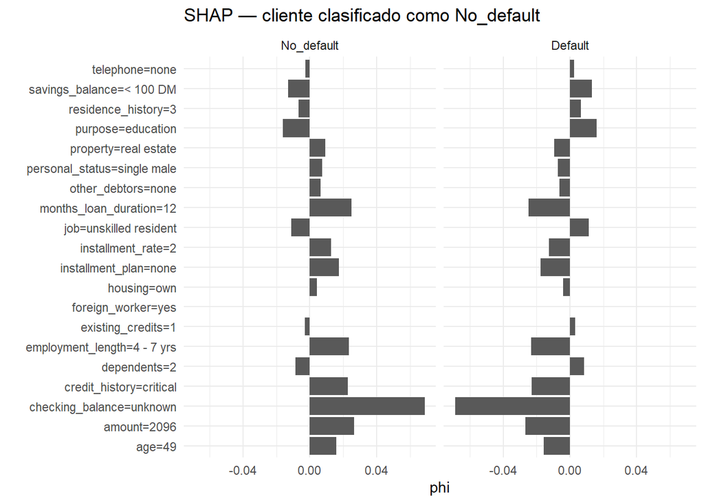

```r
# SHAP para el caso No_default
shap_nodefault <- Shapley$new(predictor, x.interest = caso_nodefault)
plot(shap_nodefault) +
  ggtitle("SHAP — cliente clasificado como No_default") +
  theme_minimal()
```

**SHAP — análisis de casos individuales:**

Los valores SHAP permiten explicar por qué el modelo clasificó a dos clientes concretos de forma diferente:

En ambos casos, `checking_balance` emerge como la variable con mayor peso en la decisión individual, confirmando su papel central tanto a nivel global como local.

Este nivel de granularidad local que proporcionan los valores SHAP es especialmente relevante en el contexto bancario, donde normativas de transparencia crediticia (como la Directiva Europea de Crédito al Consumo) exigen poder justificar de forma clara ante el cliente o ante un comité de riesgos el motivo técnico exacto de una denegación de solicitud.

**Conclusión de explicabilidad**

Las cuatro técnicas aplicadas convergen en el mismo mensaje: **el saldo en cuenta corriente** es el factor de riesgo más determinante, seguido de la duración del préstamo y la finalidad del crédito. Estos hallazgos son consistentes con el análisis exploratorio inicial y con las reglas extraídas del C5.0.

El análisis SHAP añade una dimensión adicional al confirmar que esta jerarquía de variables no solo se cumple a nivel global sino también a nivel individual: en ambos casos analizados, `checking_balance` fue la variable con mayor peso en la decisión concreta del modelo.

En definitiva, los tres modelos señalan al mismo tipo de cliente como el de mayor riesgo: alguien sin liquidez en cuenta que pide dinero prestado a largo plazo. Desde el punto de vista del banco, esto sugiere revisar con más cuidado las solicitudes de financiación superiores a 30 meses cuando el solicitante no tiene saldo positivo en cuenta, independientemente de otros factores del perfil.

## 1.6 Conclusiones finales

Este trabajo ha abordado el problema de predicción de riesgo crediticio sobre el dataset German Credit mediante un proceso analítico completo, desde la exploración de los datos hasta la aplicación de múltiples modelos de clasificación.

**Conocimiento adquirido sobre los datos:**

El análisis exploratorio reveló que la situación financiera actual del cliente es más predictiva que su perfil sociodemográfico. Las variables `checking_balance`, `credit_history` y `savings_balance` concentran la mayor capacidad discriminante, mientras que variables como `dependents`, `telephone` o `residence_history` son prácticamente irrelevantes para predecir el impago. Destaca el hallazgo contraintuitivo de que clientes con historial `fully repaid` presentan tasas de default elevadas, posiblemente porque el banco les concede créditos nuevos sin historial activo reciente.

**Resumen de modelos:**

| Modelo | Accuracy | Precisión | Recall | F1 | AUC |
| --- | --- | --- | --- | --- | --- |
| C5.0 básico | 69.8% | 50.5% | 47.1% | 48.7% | 0.689 |
| C5.0 pruning (CF=0.10) | 70.4% | 51.6% | 47.1% | 49.2% | 0.720 |
| Random Forest | 73.7% | 60.9% | 38.2% | 47.0% | 0.770 |
| XGBoost | 72.2% | 55.4% | 45.1% | 49.7% | 0.759 |

Ningún modelo supera el 50% de Recall en la clase Default, lo que refleja las limitaciones inherentes del dataset: 1.000 observaciones, variables de poder predictivo moderado y un desbalance de clases 70/30.

**Modelo recomendado:**

La elección depende del criterio priorizado. Aplicando la matriz de costes asimétrica de UCI (FN=5, FP=1), el **C5.0 con pruning** genera el menor coste económico (315 unidades) y mantiene el mejor Recall junto al C5.0 básico. Si se prioriza la capacidad discriminante global, el **Random Forest** (AUC=0.770) es la mejor opción. El **XGBoost** ofrece el mejor equilibrio entre métricas (F1=49.7%).

**Perfil de riesgo identificado:**

La concordancia de los cuatro modelos y las técnicas de explicabilidad apunta a un perfil de alto riesgo concreto: cliente con **saldo negativo en cuenta corriente**, que solicita un **préstamo de larga duración** (más de 30 meses) para financiar **su educación o un coche nuevo**. Este perfil no es una abstracción estadística sino una realidad operativa ya que, quien no tiene liquidez presente y se endeuda a largo plazo con un retorno de inversión incierto presenta sistemáticamente mayor probabilidad de impago en todos los modelos analizados.

La recomendación directa para el banco sería implementar una regla de revisión manual obligatoria para solicitudes que combinen estas tres características simultáneamente.

**Limitaciones y mejoras:**

En un entorno bancario real, estos modelos se complementarían con:

- Técnicas de balanceo de clases (SMOTE) para mejorar el Recall.
- Mayor volumen de datos.
- Variables adicionales de comportamiento financiero.
- Ajuste del umbral de clasificación según la matriz de costes.